# Predictive Modeling Techniques in Big Data Analytics: Advanced Regression and Prediction

Juan del Mazo Vázquez

Rodrigo Castro Freibott

2025-01-19

# Introduction

This report presents **Homework 2** for the course *Predictive Modeling* as part of the **Master in Big Data Analytics**. The focus is on **Advanced Regression and Prediction** (Topic 3), building upon foundational concepts of linear and generalized linear models. The main objectives are:

The objective of this study is to apply advanced regression and prediction techniques to analyze and forecast outcomes in the **Sales Dataset**.This dataset includes various predictors, such as investments in advertising channels (e.g., Meta, TikTok, TV, Radio), web traffic, and other marketing-related factors, alongside the target variable, sales.

The **objectives** of this analysis are:

- **Predictive Accuracy**: Developing robust predictive models using advanced regression techniques.
- **Interpretability and Insights**: Exploring the relationships between investment-related variables and predicted sales to provide actionable insights for optimizing marketing strategies.

The analysis was **structured** as follows to ensure a systematic and comprehensive approach:

1. **Data Preparation**: Load and preprocess the datasets, addressing missing values, transforming variables, and engineering additional features.
2. **Exploratory Data Analysis (EDA)**: Visualize the distribution of key variables, analyze their relationship with the target, and study their sparsity.
3. **Predictive Analysis**: Train multiple advanced regression models, including regularization methods (Elastic Net), tree-based methods (Random Forest, XGBoost), k-Nearest Neighbors (KNN), neural networks, and ensemble approaches (stacking and weighted ensembles).
4. **Hyperparameter Tuning**: Optimize hyperparameters for each model using cross-validation on a training dataset.
5. **Model Evaluation**: Evaluate models using Mean Absolute Error (MAE) on a validation dataset.
6. **Submission of Predictions**: Retrain selected models on the combined dataset and generate final predictions for the testing dataset (with unknown ground-truth sales).
7. **Final Analysis**: Conduct a detailed analysis of investment-related variables to provide actionable recommendations for future strategies.

# Libraries Used

The following R libraries were employed to streamline the analysis and meet the explanatory requirements of the task:

## Libraries and Their Functions:

- **tidyverse**: A collection of R packages designed for seamless data science tasks such as:
  - Data manipulation (`dplyr`)
  - Visualization (`ggplot2`)
  - Data tidying (`tidyr`)
- **caret**: A powerful library for machine learning tasks, including:
  - Data partitioning
  - Training models
  - Model performance evaluation
- **glmnet**: Implements elastic net regularization, including Lasso and Ridge regression.
- **randomForest**: A popular package for training Random Forest models.
- **xgboost**: An optimized gradient boosting framework designed for speed and performance.
- **broom**: Provides tools to cleanly organize statistical outputs (e.g., regression summaries) into tidy data frames.
- **tidymodels**: A collection of packages to streamline machine learning workflows, including data splitting, model building, and evaluation, with a consistent framework.
- **patchwork**: A library designed to simplify the creation of multi-panel plots by combining individual ggplot2 objects into a cohesive layout. This is particularly useful when visualizing relationships or comparisons across multiple variables in a single view. It allows users to arrange plots using a simple grammar, enabling flexible layouts without requiring complex coding.
- **reshape2**: Assists in reshaping data to formats suitable for heatmaps or other visualizations.
- **gridExtra**: Facilitates the arrangement of multiple plots into cohesive visual layouts.

## Installation and Loading

To ensure reproducibility, the following libraries were installed and loaded at the beginning of the analysis:

```r
# Install necessary packages
# install.packages(c("tidyverse", "caret", "glmnet", "randomForest", "xgboost", "broom", "tidymodels", "patchwork", "reshape2", "gridExtra", "ggpubr"), repos = "https://cran.r-project.org")

# Load libraries
library(tidyverse)
library(caret)
library(glmnet)
library(randomForest)
library(xgboost)
library(broom)
library(tidymodels)
library(patchwork)
library(reshape2)
library(gridExtra)
library(ggpubr)
```

# Dataset Description

## Dataset Content:

The dataset provides information on sales and various predictors, including investment-related variables and online/offline factors. Below is a representative subset of the features:

- **Monday_date**: Start date of the week (Monday).
- **Sales**: Weekly sales in numerical format.
- **Stores**: Number of physical stores contributing to sales.
- **Affiliates_investment**: Spend on affiliate marketing programs.
- **Meta_investment**: Spend on Facebook/Instagram advertising.
- **Sea_brand**: Spend on branded search engine advertisement (SEA).
- **Sea_other_investment**: Spend on non-branded SEA.
- **TikTok_investment**: Spend on TikTok advertising.
- **Web_visits**: Weekly visits to the company’s website.
- **GBP**: Local positioning on Google (business visibility).
- **Database_investment**: Spend on customer relationship management or database marketing.
- **OOH_investment**: Spend on out-of-home ads (e.g., billboards).
- **TV_hbtv_investment**: Spend on connected TV ads (streaming platforms).
- **TV_investment**: Spend on traditional TV ads.
- **Radio_investment**: Spend on radio ads.

All features are **Numerical Variables** (there are no categorical features).

# Loading the Dataset

The dataset is loaded into R for further analysis. Below, the dataset is displayed to gain an initial understanding of its structure and content.

```r
# Load the dataset
sales_data <- readxl::read_excel("Real_Dataset_HW2.xlsx")

# Display the dataset
sales_data
```

| Monday_date | Sales | Stores | Affiliates_investment | Meta_investment | sea_brand | sea_other_investment | tiktok_investment | web_visits | GBP | Database_investment | OOH_investment | TV_hbtv_investment | TV_investment | Radio_investment |
| --- | --- | --- | --- | --- | --- | --- | --- | --- | --- | --- | --- | --- | --- | --- |
| 2022-01-03 | 1784 | 343 | 75438.0 | 1507.730 | 5612.98 | 4277.98 | 0.00 | 37616 | 9158 | 13765.000 | 7276.096 | 0.000 | 0.00 | 3990.5346 |
| 2022-01-10 | 3550 | 343 | 31834.0 | 28946.820 | 5889.35 | 7276.61 | 0.00 | 37616 | 12656 | 13765.000 | 7276.096 | 0.000 | 86647.33 | 10451.4001 |
| 2022-01-17 | 3849 | 343 | 16898.0 | 18356.520 | 4363.21 | 8329.27 | 0.00 | 37616 | 11402 | 13765.000 | 7276.096 | 0.000 | 86647.33 | 0.0000 |
| 2022-01-24 | 4172 | 343 | 21278.0 | 6320.860 | 6813.07 | 10015.02 | 2053.84 | 37616 | 11280 | 13765.000 | 7276.096 | 0.000 | 86647.33 | 0.0000 |
| 2022-01-31 | 3971 | 343 | 45546.0 | 13617.160 | 9635.79 | 17285.06 | 250.37 | 46616 | 10415 | 13765.000 | 7276.096 | 0.000 | 86647.33 | 0.0000 |
| 2022-02-07 | 4226 | 345 | 49762.0 | 17000.760 | 9938.63 | 19481.59 | 0.00 | 46765 | 11588 | 13856.250 | 7193.870 | 0.000 | 86647.33 | 0.0000 |
| 2022-02-14 | 4268 | 345 | 46150.0 | 26598.100 | 11711.30 | 23328.60 | 1618.39 | 46971 | 11117 | 13856.250 | 7193.870 | 0.000 | 117897.85 | 0.0000 |
| 2022-02-21 | 4381 | 345 | 31858.0 | 35895.980 | 10891.56 | 32610.12 | 1118.70 | 56888 | 10957 | 13856.250 | 7193.870 | 0.000 | 117897.85 | 0.0000 |
| 2022-02-28 | 3618 | 345 | 43674.0 | 16837.210 | 16468.17 | 25587.83 | 76.85 | 47274 | 10670 | 13856.250 | 7193.870 | 0.000 | 117897.85 | 0.0000 |
| 2022-03-07 | 4060 | 347 | 56812.0 | 22094.950 | 13310.49 | 23185.57 | 1437.00 | 51523 | 11321 | 12537.500 | 10938.870 | 0.000 | 117897.85 | 0.0000 |

[output cut: 132 more lines]

# Data Cleaning

In this section, the dataset is cleaned, and summary statistics are computed both before and after the cleaning process. The process involves splitting the data into training and test sets, followed by handling missing data, transforming variables, and preparing the dataset for predictive modeling.

## Initial Dataset Exploration: Summary Statistics

Before performing the cleaning process, summary statistics for numerical features were calculated to understand the initial state of the dataset. Key metrics, including mean, median, and standard deviation, are presented below to provide an overview of the dataset’s structure and variability. This analysis helps identify potential issues such as skewness, outliers, or inconsistencies that need to be addressed during the data cleaning process.

```r
# Calculate summary statistics for numerical features
sales_summary <- sales_data %>%
  summarise(
    across(where(is.numeric),
           list(
             Mean = ~round(mean(.x, na.rm = TRUE), 2),
             Median = ~round(median(.x, na.rm = TRUE), 2),
             SD = ~round(sd(.x, na.rm = TRUE), 2)
           ))
  )

# Create clean dataframe with just the statistics we want
sales_summary_clean <- data.frame(
  Mean = unlist(sales_summary[grep("_Mean$", names(sales_summary))]),
  Median = unlist(sales_summary[grep("_Median$", names(sales_summary))]),
  SD = unlist(sales_summary[grep("_SD$", names(sales_summary))])
)

# Add row names (features) without the _Mean suffix
row.names(sales_summary_clean) <- names(sales_data)[sapply(sales_data, is.numeric)]

# Display results
cat("\nSummary Statistics:\n")
```

```
##
## Summary Statistics:
```

```r
print(sales_summary_clean)
```

```
##                           Mean   Median       SD
## Sales                  3957.19  4117.00   671.92
## Stores                  374.44   381.00    13.69
## Affiliates_investment 26054.07 20787.30 19878.99
## Meta_investment       27556.04 26005.70 12468.78
## sea_brand             13710.77 12356.01  5779.83
## sea_other_investment  39012.23 36146.04 19688.38
## tiktok_investment       435.02     0.00   640.01
## web_visits            79033.41 70326.50 33183.26
## GBP                   10277.63 10356.50  1047.85
## Database_investment   10697.84 10560.00  4525.82
## OOH_investment        15874.37 13631.81  6774.99
## TV_hbtv_investment     4113.98  6774.19  3337.12
## TV_investment         63234.52 67331.82 34753.60
## Radio_investment       9095.94  1013.47 12622.80
```

These statistics reveal the current **investment behavior** of the company behind the dataset:

- TV is the dominant advertising channel (€63,235 average spend).
- In contrast, there is minimal, sporadic use of TikTok advertisement (€435 mean, €0 median).
- Sales performance is stable (€3,957 mean with SD €672).
- SEA (Search) strategy prioritizes non-branded terms (€39,012) over branded terms (€13,711), suggesting focus on customer acquisition.
- Radio shows highly variable investment (€9,096 mean but €1,013 median), indicating campaign-based usage rather than consistent spending.
- The number of stores shows little variability (374 mean with SD 14).

## Splitting the Data into Training, Validation and Testing Sets

The data is split into two primary sets, with the first set further split into two smaller sets:

- **Training Set** (80% of all data): Contains rows with non-missing values in the `Sales` column, which will be used for training and validating the models. This dataset is further split into:
  - **Training CV Set** (80% of training set): Used to train the models. This set will be further split into several folds to perform hyperparameter tuning with cross-validation (CV).
  - **Validation Set** (20% of training set): Used to evaluate the models on new, unseen data.
- **Test Set** (20% of all data): Contains rows where `Sales` values are missing, to be used for final prediction.

Given the **time dependencies** in the dataset, it is crucial to:

- Before the training/validation split, **NOT randomly shuffling** the dataset.
- When doing hyperparameter tuning on the training CV dataset, **using a time cross-validation approach**.

The following code in R implements these data splits.

```r
# Split the data into training and test sets based on the presence of Sales values
train_sales_data <- sales_data %>% filter(!is.na(Sales))
test_sales_data <- sales_data %>% filter(is.na(Sales))

# Sort data chronologically
train_sales_data <- train_sales_data %>%
  arrange(Monday_date)

# Split training data into training CV and validation CV with time-based split (no random shuffling)
total_weeks <- nrow(train_sales_data)
validation_size <- floor(0.2 * total_weeks)
split_index <- total_weeks - validation_size
train_cv <- train_sales_data[1:split_index, ]
val_cv <- train_sales_data[(split_index + 1):total_weeks, ]

# Parameters for time series split of training CV using cross-validation
n_iter_cv <- 3  # Desired number of CV iterations
train_cv_weeks = nrow(train_cv)
initial_window <- floor(0.5 * train_cv_weeks)  # 50% of data for initial training
assessment_size <- floor((train_cv_weeks - initial_window) / n_iter_cv)  # Size of each assessment period
ctrl <- trainControl(
  method = "timeslice",         # Use time series cross-validation
  initialWindow = initial_window,  # Number of weeks in initial window
  horizon = assessment_size,     # Number of weeks to predict
  skip = assessment_size - 1,   # Skip to next non-overlapping period
  fixedWindow = TRUE,          # Use fixed-size training window
  allowParallel = TRUE,        # Enable parallel processing
  verboseIter = TRUE          # Display progress during training
)

# Print the CV structure
cat("CV Parameters:\n")
```

```
## CV Parameters:
```

```r
cat("Total weeks in training data:", total_weeks, "\n")
```

```
## Total weeks in training data: 117
```

```r
cat("Number of CV iterations:", n_iter_cv, "\n")
```

```
## Number of CV iterations: 3
```

```r
cat("Initial window size (weeks):", initial_window, "\n")
```

```
## Initial window size (weeks): 47
```

```r
cat("Assessment size (weeks):", assessment_size, "\n\n")
```

```
## Assessment size (weeks): 15
```

```r
cat("Data Splits:\n")
```

```
## Data Splits:
```

```r
cat("Training period:", format(min(train_cv$Monday_date)), "to", format(max(train_cv$Monday_date)), "\n")
```

```
## Training period: 2022-01-03 to 2023-10-16
```

```r
cat("Validation period:", format(min(val_cv$Monday_date)), "to", format(max(val_cv$Monday_date)), "\n")
```

```
## Validation period: 2023-10-23 to 2024-03-25
```

```r
cat("Test period:", format(min(test_sales_data$Monday_date)), "to", format(max(test_sales_data$Monday_date)), "\n")
```

```
## Test period: 2024-04-01 to 2024-09-16
```

We can **visualize the data partitions** with the following code. To visualize the folds generated with cross-validation, we will train a dummy model and extract the fold information from caret:

```r
# Extract fold indices from caret's trainControl
# First create a dummy model to get the folds
set <- train_cv  # Use our training CV data
dummy_model <- train(
  Sales ~ Meta_investment,  # Simplest possible model
  data = set,
  method = "lm",  # Linear regression
  trControl = ctrl
)
# Extract the resampling indices
resample_indices <- dummy_model$control$index
assessment_indices <- dummy_model$control$indexOut

# Print fold information
cat("\nFold Information from caret:\n")
```

```
##
## Fold Information from caret:
```

```r
for(i in seq_along(resample_indices)) {
  cat(sprintf("\nFold %d:\n", i))
  cat(sprintf("Training: %d observations (%s to %s)\n",
              length(resample_indices[[i]]),
              format(min(train_cv$Monday_date[resample_indices[[i]]])),
              format(max(train_cv$Monday_date[resample_indices[[i]]]))))
  cat(sprintf("Assessment: %d observations (%s to %s)\n",
              length(assessment_indices[[i]]),
              format(min(train_cv$Monday_date[assessment_indices[[i]]])),
              format(max(train_cv$Monday_date[assessment_indices[[i]]]))))
}
```

```
##
## Fold 1:
## Training: 47 observations (2022-01-03 to 2022-11-21)
## Assessment: 15 observations (2022-11-28 to 2023-03-06)
##
## Fold 2:
## Training: 47 observations (2022-04-18 to 2023-03-06)
## Assessment: 15 observations (2023-03-13 to 2023-06-19)
##
## Fold 3:
## Training: 47 observations (2022-08-01 to 2023-06-19)
## Assessment: 15 observations (2023-06-26 to 2023-10-02)
```

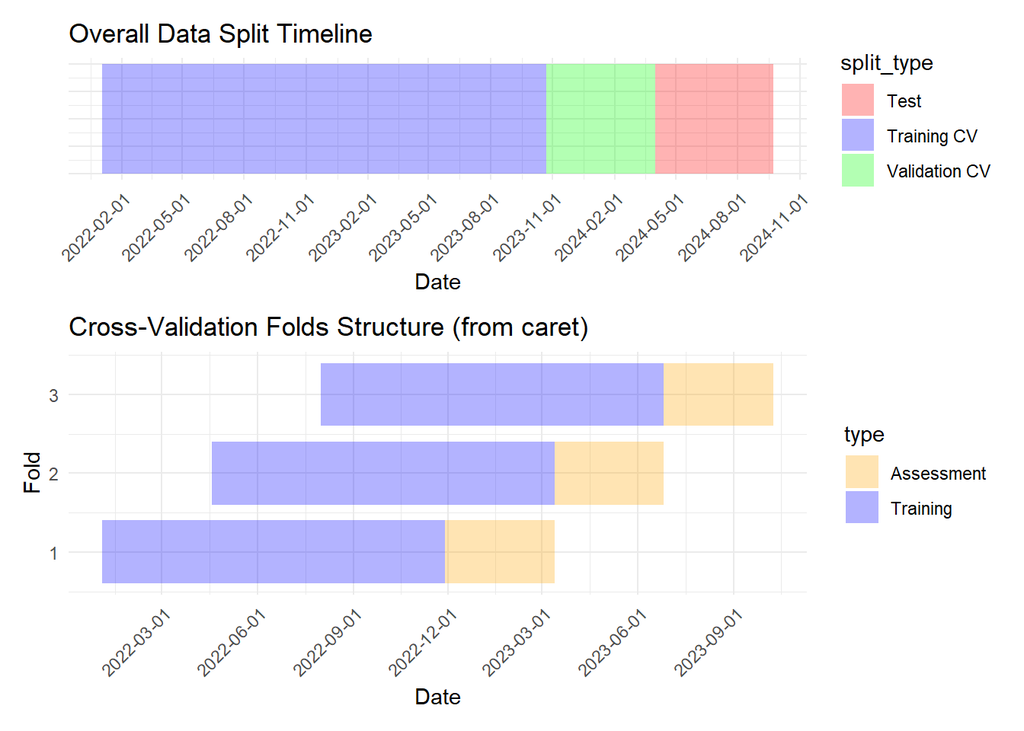

```r
# Create a data frame for visualization of all splits
# Add next_date column to handle the geom_rect xmax properly
splits_df <- data.frame(
  Monday_date = c(train_cv$Monday_date, val_cv$Monday_date, test_sales_data$Monday_date),
  split_type = c(
    rep("Training CV", nrow(train_cv)),
    rep("Validation CV", nrow(val_cv)),
    rep("Test", nrow(test_sales_data))
  )
) %>%
  arrange(Monday_date) %>%
  mutate(
    next_date = lead(Monday_date, default = Monday_date[n()] + days(7))
  )

# Create CV folds DataFrame using caret's indices
cv_folds <- data.frame()

for(i in seq_along(resample_indices)) {
  # Add training period
  cv_folds <- rbind(cv_folds, data.frame(
    Monday_date = train_cv$Monday_date[resample_indices[[i]]],
    fold = paste("Fold", i),
    type = "Training"
  ))

  # Add assessment period
  cv_folds <- rbind(cv_folds, data.frame(
    Monday_date = train_cv$Monday_date[assessment_indices[[i]]],
    fold = paste("Fold", i),
    type = "Assessment"
  ))
}

# Add next_date column for cv_folds
cv_folds <- cv_folds %>%
  arrange(fold, Monday_date) %>%
  group_by(fold, type) %>%
  mutate(
    next_date = lead(Monday_date, default = Monday_date[n()] + days(7))
  ) %>%
  ungroup()

# Create the main timeline plot
main_split_plot <- ggplot() +
  geom_rect(data = splits_df,
            aes(xmin = Monday_date,
                xmax = next_date,
                ymin = 0,
                ymax = 1,
                fill = split_type),
            alpha = 0.3) +
  scale_fill_manual(values = c("Training CV" = "blue",
                              "Validation CV" = "green",
                              "Test" = "red")) +
  scale_x_datetime(date_labels = "%Y-%m-%d", date_breaks = "3 months") +
  labs(title = "Overall Data Split Timeline",
       x = "Date",
       y = "") +
  theme_minimal() +
  theme(axis.text.y = element_blank(),
        axis.ticks.y = element_blank(),
        axis.text.x = element_text(angle = 45, hjust = 1))

# Create the CV folds plot
cv_folds_plot <- ggplot() +
  geom_rect(data = cv_folds,
            aes(xmin = Monday_date,
                xmax = next_date,
                ymin = as.numeric(factor(fold)) - 0.4,
                ymax = as.numeric(factor(fold)) + 0.4,
                fill = type),
            alpha = 0.3) +
  scale_fill_manual(values = c("Training" = "blue",
                              "Assessment" = "orange")) +
  scale_x_datetime(date_labels = "%Y-%m-%d", date_breaks = "3 months") +
  labs(title = "Cross-Validation Folds Structure (from caret)",
       x = "Date",
       y = "Fold") +
  theme_minimal() +
  theme(axis.text.x = element_text(angle = 45, hjust = 1))

# Combine plots using patchwork
combined_plot <- main_split_plot / cv_folds_plot +
  plot_layout(heights = c(1, 2))

# Display the combined plot
print(combined_plot)
```

## Handling Missing Values

The following code checks for **the presence of `NA` values** in all columns of the respective datasets:

```r
# Check for NA values in training (train_cv), validation (val_cv), and test datasets
na_summary_train <- train_sales_data %>%
  summarise(across(everything(), ~sum(is.na(.)))) %>%
  pivot_longer(cols = everything(), names_to = "Variable", values_to = "NA_Count")

na_summary_test <- test_sales_data %>%
  summarise(across(everything(), ~sum(is.na(.)))) %>%
  pivot_longer(cols = everything(), names_to = "Variable", values_to = "NA_Count")

# Display summaries of NA values
print("NA Summary for Training Set (train_sales_data):")
```

```
## [1] "NA Summary for Training Set (train_sales_data):"
```

```r
print(na_summary_train)
```

```
## # A tibble: 15 × 2
##    Variable              NA_Count
##    <chr>                    <int>
##  1 Monday_date                  0
##  2 Sales                        0
##  3 Stores                       0
##  4 Affiliates_investment        0
##  5 Meta_investment              0
##  6 sea_brand                    0
##  7 sea_other_investment         0
##  8 tiktok_investment            0
##  9 web_visits                   0
## 10 GBP                          0
## 11 Database_investment          0
## 12 OOH_investment               0
## 13 TV_hbtv_investment           0
## 14 TV_investment                0
## 15 Radio_investment             0
```

```r
print("NA Summary for Test Set (test_sales_data):")
```

```
## [1] "NA Summary for Test Set (test_sales_data):"
```

```r
print(na_summary_test)
```

```
## # A tibble: 15 × 2
##    Variable              NA_Count
##    <chr>                    <int>
##  1 Monday_date                  0
##  2 Sales                       25
##  3 Stores                       0
##  4 Affiliates_investment        0
##  5 Meta_investment              0
##  6 sea_brand                    0
##  7 sea_other_investment         0
##  8 tiktok_investment            0
##  9 web_visits                   0
## 10 GBP                          0
## 11 Database_investment          0
## 12 OOH_investment               0
## 13 TV_hbtv_investment           0
## 14 TV_investment                0
## 15 Radio_investment             0
```

After inspecting the datasets, **no explicit missing values (`NA`) are found in either the training or validation sets**, except for the `Sales` column in the test set. These `NA` values are expected and represent the absence of sales data for the test period, which aligns with the task requirements.

## Handling Zero Values

Zero values in certain columns may represent valid observations (e.g., no investment during a given week) or potential anomalies (e.g., zero web visits). To handle these appropriately:

- **Investment-Related Variables**: Zeros are likely valid and represent weeks with no investment. These zeros are retained without modification.
- **Potential Anomalies**: For variables like `web_visits`, zeros might indicate data inconsistencies.

The following code computes zero counts for all columns in the training set:

```r
# Define investment-related variables
investment_vars <- c(
  "Affiliates_investment",
  "Meta_investment",
  "sea_brand",
  "sea_other_investment",
  "tiktok_investment",
  "Database_investment",
  "OOH_investment",
  "TV_hbtv_investment",
  "TV_investment",
  "Radio_investment"
)

# Count zero values in training set
zero_counts_train <- train_sales_data %>%
  summarise(across(everything(), ~sum(. == 0, na.rm = TRUE))) %>%
  pivot_longer(cols = everything(), names_to = "Variable", values_to = "ZeroCount") %>%
  mutate(ZeroPercentage = ZeroCount / nrow(train_cv) * 100)

# Display summaries of zero counts for training set
print("Zero Counts in Training Set:")
```

```
## [1] "Zero Counts in Training Set:"
```

```r
print(zero_counts_train)
```

```
## # A tibble: 15 × 3
##    Variable              ZeroCount ZeroPercentage
##    <chr>                     <int>          <dbl>
##  1 Monday_date                   0            0
##  2 Sales                         0            0
##  3 Stores                        0            0
##  4 Affiliates_investment         0            0
##  5 Meta_investment               0            0
##  6 sea_brand                     0            0
##  7 sea_other_investment          0            0
##  8 tiktok_investment            55           58.5
##  9 web_visits                    0            0
## 10 GBP                           0            0
## 11 Database_investment           0            0
## 12 OOH_investment                0            0
## 13 TV_hbtv_investment           50           53.2
## 14 TV_investment                12           12.8
## 15 Radio_investment             41           43.6
```

We notice **the only variables with zeros correspond to investments**, so they are likely genuine values:

- `tiktok_investment`, `TV_hbtv_investment`, and `Radio_investment` have zeros in approximately half of the rows. This reflects weeks with no TikTok, streaming TV or radio campaigns.
- `TV_investment` has zeros in 13% of the rows.

# Exploratory Data Analysis (EDA)

The primary aim of this Exploratory Data Analysis (EDA) is to better understand the structure of the dataset, identify patterns, and evaluate the relationships between variables, particularly investment-related predictors and the target variable (sales). The insights gained in this phase will guide the subsequent feature engineering and predictive modeling steps.

## Analysis of the Target

The target variable, `Sales`, represents weekly sales figures. Understanding its distribution is critical because:

- It determines how well the data aligns with assumptions required for regression-based models, such as linearity and normality of residuals.
- It helps identify outliers and patterns (e.g., skewness, multimodality).

This analysis is focused on the cross-validation training dataset (`train_cv`) because it will be used for model training. `Sales` values are not available in the test set, aligning with the task of making predictions.

The following histogram visualizes the original distribution of `Sales`:

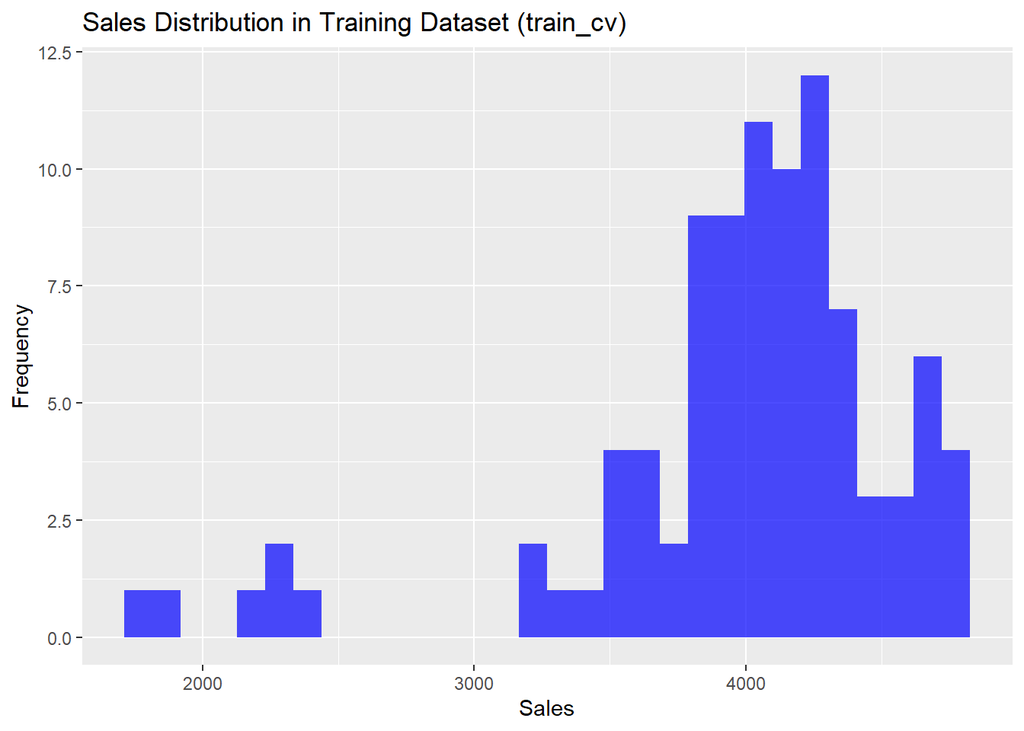

```r
# Original Sales Distribution in the Cross-Validation Training Dataset (train_cv)
ggplot(train_cv, aes(x = Sales)) +
  geom_histogram(fill = "blue", bins = 30, alpha = 0.7) +
  labs(
    title = "Sales Distribution in Training Dataset (train_cv)",
    x = "Sales",
    y = "Frequency"
  )
```

Due to the skewness and outliers, the original sales values violate the assumptions of linear regression models. However, there should be no issue when using Machine Learning models such as Random Forest, since they have no homoscedasticity or normality assumptions.

In order to apply linear regression models successfully, we will see if applying a **log transformation** improves the behaviour of the distribution:

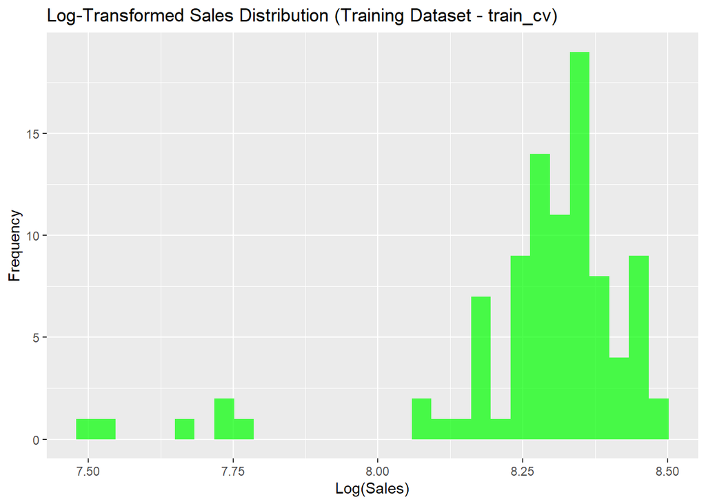

```r
# Visualize Log-Transformed Sales Distribution for the Training Dataset
ggplot(train_cv, aes(x = log(Sales + 1))) +
  geom_histogram(fill = "green", bins = 30, alpha = 0.7) +
  labs(
    title = "Log-Transformed Sales Distribution (Training Dataset - train_cv)",
    x = "Log(Sales)",
    y = "Frequency"
  )
```

These observations of the target yields the following **implications for modeling**:

- **Logarithmic Transformation of the Target With Linear Models:** We must predict the log-transformed sales when using linear regression. Therefore, we will use a formula like `log(Sales) ~ .`.
- **Original Target With Machine Learning:** Since Machine Learning algorithms make no normality or homoscedasticity assumptions about the target, we can apply them with the original sales values directly. Therefore, we will use a formula like `Sales ~ .`.

## Analysis of Investment Variables

Investment-related features, such as spending on Meta, Affiliates, TikTok, and traditional media, are central to this project. The following steps were performed to evaluate their distributions and their relationships with Sales.

### Distribution of Investment Features

The histograms below display the distributions of key investment variables, grouped by online, offline, and traditional media investments. This analysis focuses on the training set as it forms the foundation for model training. The validation and test sets, while undergoing similar preprocessing, are excluded from visualization to prevent potential data leakage.

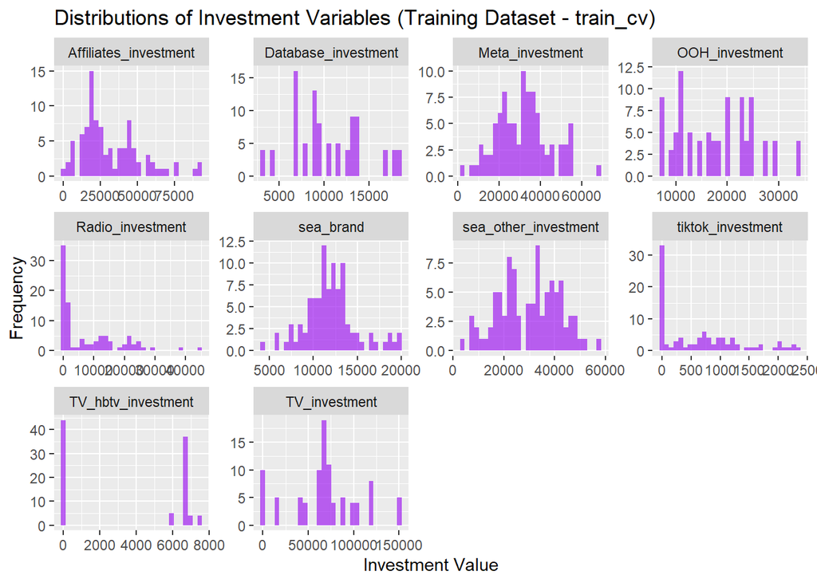

```r
# Plot distributions of investment variables in the training dataset
train_cv %>%
  select(all_of(investment_vars)) %>%
  pivot_longer(cols = everything(), names_to = "Variable", values_to = "Value") %>%
  ggplot(aes(x = Value)) +
  geom_histogram(fill = "purple", bins = 30, alpha = 0.7) +
  facet_wrap(~Variable, scales = "free") +
  labs(
    title = "Distributions of Investment Variables (Training Dataset - train_cv)",
    x = "Investment Value",
    y = "Frequency"
  )
```

- **High Proportion of Zeros**: Variables such as `tiktok_investment`, `TV_hbtv_investment`, and `Radio_investment` contain a significant number of zeros, as evident from the histograms. As explained above, these zeros represent weeks with no investment in these channels, indicating meaningful observations rather than missing values.
- **Skewed Distributions**: Some investment variables, including `Affiliates_investment` and `Database_investment`, exhibit right-skewed distributions. The variables with many zeros (`tiktok_investment`, `TV_hbtv_investment`, and `Radio_investment`) also have an extremely skewed distribution as a consequence of their high number of zeros.
- **More Symmetric Distributions**: On the other hand, variables like `Meta_investment`, `sea_brand`, `sea_other_investment`, `TV_investment`, and `OOH_investment` show relatively less skewed distributions and may not require transformation.

These observations about the investment features yield the following **implications for modeling**:

- **Zero Handling**: To capture patterns related to non-investment periods, zero-indicator columns should be included in the dataset for the `tiktok_investment`, `TV_hbtv_investment`, and `Radio_investment` columns. These additional columns will be 1 when the corresponding investment variable is 0, and they will be 0 otherwise.
- **Original Distribution of Features**: Despite observing severe skewness in many distributions, this is not an issue with either linear or Machine Learning models. Linear models only assume symmetry in the target (the residuals), not the features. Logarithm transformations are only necessary if they help make the relationships more linear, which will be analyzed in the next section.

### Relationship Between Investments and Sales

To better understand the impact of investments on sales, scatter plots are generated to examine the relationships between key investment variables and the target variable. This analysis is conducted on the training CV dataset to avoid introducing bias from the validation or test sets.

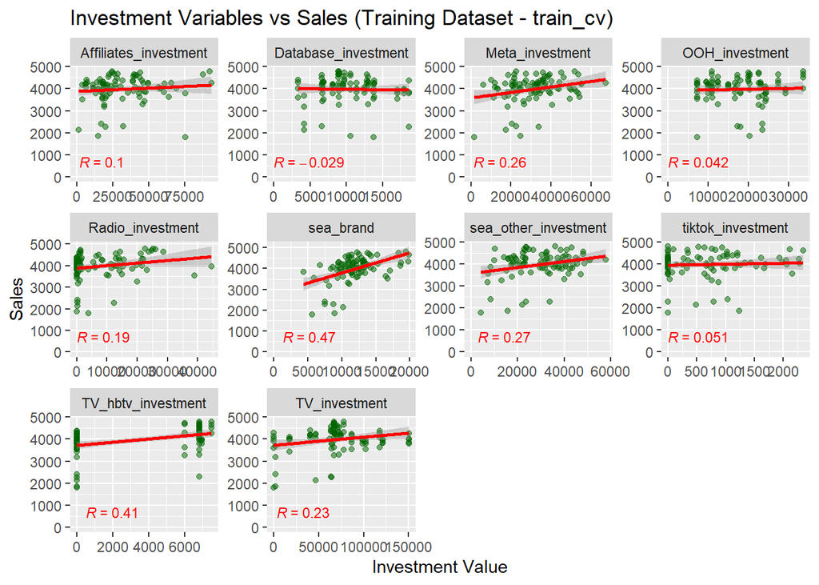

```r
# Original scale plots
train_cv %>%
 pivot_longer(cols = all_of(investment_vars), names_to = "Variable", values_to = "Value") %>%
 ggplot(aes(x = Value, y = Sales)) +
 geom_point(alpha = 0.5, color = "darkgreen") +
 geom_smooth(method = "lm", formula = y ~ x, color = "red", se = TRUE) +
 facet_wrap(~Variable, scales = "free") +
 stat_cor(method = "pearson",
          label.x = 0.1,
          label.y = 0.9,
          size = 3,
          color = "red",
          label.sep = "\n") +  # Only show Pearson
 labs(
   title = "Investment Variables vs Sales (Training Dataset - train_cv)",
   x = "Investment Value",
   y = "Sales"
 )
```

- **Positive Trends**: Higher investments in Meta, SEA, Radio and TV generally correspond to higher sales, confirming a positive relationship. For these values, there is a relatively high and positive Pearson correlation coefficient.
- **Weak Relationships**: For investments in affiliate programs, database, OOH ads, or TikTok, the relationship is weaker and less consistent. In these cases, the correlation coefficient is very low.
- **Non-Linear Relationships**: The scatter plots reveal diminishing returns: while low-to-moderate investments yield substantial increases in sales, the effect diminishes at higher investment levels.

To improve results on linear models, we will see if relationships become more linear when applying a **logarithmic transformation on the target and features**:

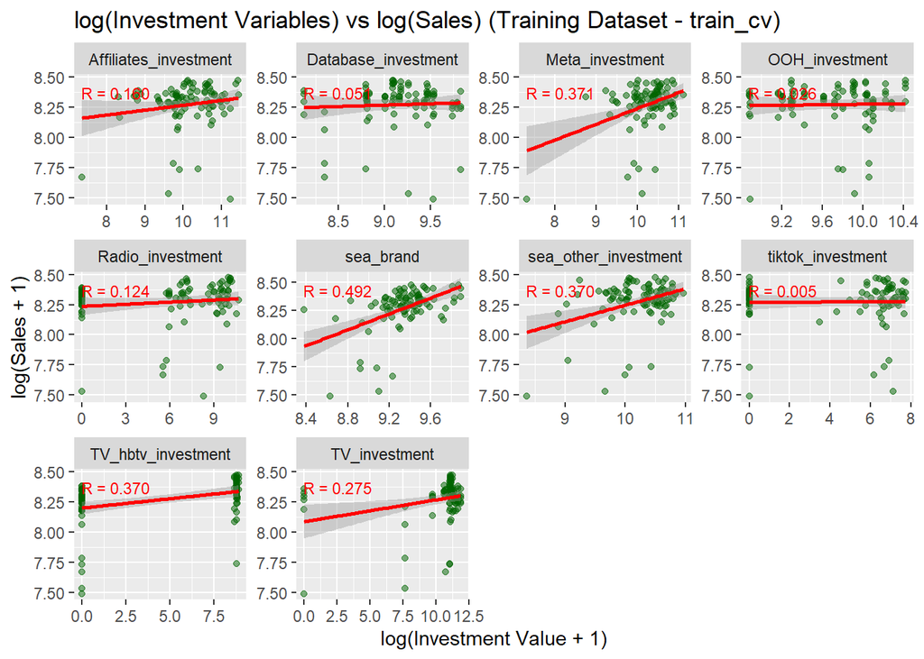

```r
# Generate scatter plots for all investment variables vs Log(Sales) in train_cv
correlations_log <- train_cv %>%
  pivot_longer(cols = all_of(investment_vars), names_to = "Variable", values_to = "Value") %>%
  group_by(Variable) %>%
  summarise(correlation = cor(log(Value + 1), log(Sales + 1), method = "pearson"))
train_cv %>%
  pivot_longer(cols = all_of(investment_vars), names_to = "Variable", values_to = "Value") %>%
  ggplot(aes(x = log(Value + 1), y = log(Sales + 1))) +
  geom_point(alpha = 0.5, color = "darkgreen") +
  geom_smooth(method = "lm", color = "red", formula = y ~ x, se = TRUE) +
  geom_text(data = correlations_log,
            aes(x = -Inf, y = Inf,
                label = sprintf("R = %.3f", correlation)),
            hjust = -0.1,
            vjust = 2,
            color = "red",
            size = 3) +
  facet_wrap(~Variable, scales = "free") +
  labs(
    title = "log(Investment Variables) vs log(Sales) (Training Dataset - train_cv)",
    x = "log(Investment Value + 1)",
    y = "log(Sales + 1)"
  )
```

We notice applying logarithmic transformations has the following effects:

- **Investment in affiliate programs, SEA, and Meta**: When considering the log-transformed values, the relationship looks more linear and the correlation coefficient is higher.
- **Investment in OOH and TikTok advertisement**: The log-transformed scatter plots confirm a weak correlation of these features with the target.
- **TV and Radio investment**: Applying the logarithmic transformations did not consistently increase the correlation coefficient in these cases, although the relationships still look relatively linear.

These observations about the relationships between the target and the investment features yield the following **implications for modeling**:

- **Logarithmic Transformation of the Features With Linear Models:** Due to the linearity assumption of linear models, we must use the log-transformed features to strengthen linear relationships with the target. Therefore, we will use a formula like `log(Sales) ~ log(Meta_investment)`.
- **Original Features With Machine Learning:** Since Machine Learning algorithms make no linearity assumptions, we can apply them with the original feature values directly. Therefore, we will use a formula like `Sales ~ Meta_investment`.

## Analysis of the Stores Column

The `Stores` column represents the total number of stores in operation. We will now compute summary statistics and plot its histogram to understand its distribution and range:

```r
# Compute summary statistics for the Stores column in train_cv
stores_summary_train_cv <- train_cv %>%
  summarise(
    Min = min(Stores, na.rm = TRUE),
    Max = max(Stores, na.rm = TRUE),
    Mean = mean(Stores, na.rm = TRUE),
    Median = median(Stores, na.rm = TRUE),
    Unique_Count = n_distinct(Stores)
  )

print("Summary Statistics for Stores (Training Set - train_cv):")
```

```
## [1] "Summary Statistics for Stores (Training Set - train_cv):"
```

```r
print(stores_summary_train_cv)
```

```
## # A tibble: 1 × 5
##     Min   Max  Mean Median Unique_Count
##   <dbl> <dbl> <dbl>  <dbl>        <int>
## 1   343   383  368.    371           19
```

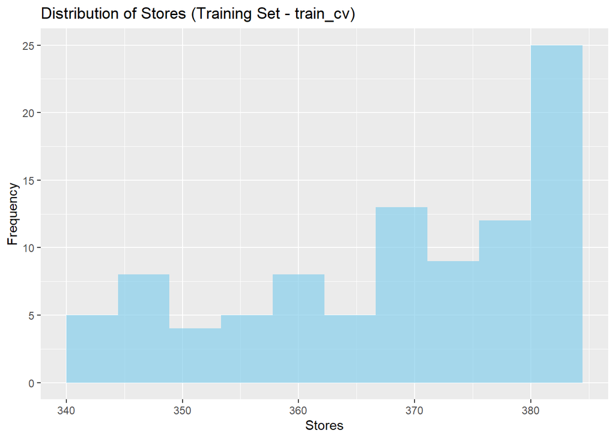

```r
# Visualize the distribution of Stores in train_cv
ggplot(train_cv, aes(x = Stores)) +
  geom_histogram(fill = "skyblue", bins = 10, alpha = 0.7) +
  labs(
    title = "Distribution of Stores (Training Set - train_cv)",
    x = "Stores",
    y = "Frequency"
  )
```

We notice that, although `Stores` is count-based (discrete in theory), it behaves like a quasi-continuous variable for analysis purposes because it varies smoothly without abrupt jumps. Therefore, this column behaves like a **numerical and continuous variable**, so it can be used for correlation analysis and predictive modeling without transformation.

## Correlation Analysis of Investment Features and Sales

To assess the relationships between numerical features and `Sales`, the correlation matrix is computed for the training cross-validation set. This analysis provides insights into the strength and direction of associations between investment variables and sales performance.

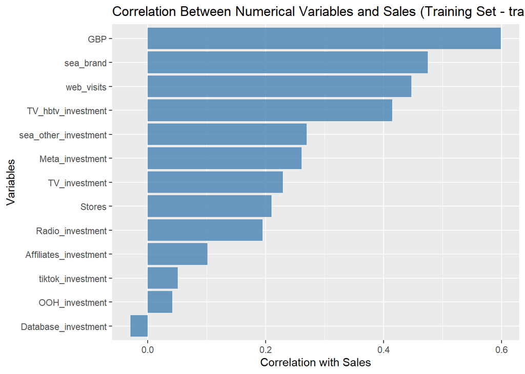

```r
# Select all numerical variables, including Sales
numerical_vars <- train_cv %>%
  select(where(is.numeric), Sales)

# Compute correlation matrix
correlation_matrix <- cor(numerical_vars, use = "complete.obs")

# Extract correlations with Sales
corr_data <- as.data.frame(as.table(correlation_matrix)) %>%
  filter(Var1 == "Sales" & Var2 != "Sales") %>%
  arrange(desc(Freq))

# Plot correlations
ggplot(corr_data, aes(x = reorder(Var2, Freq), y = Freq)) +
  geom_bar(stat = "identity", fill = "steelblue", alpha = 0.8) +
  coord_flip() +
  labs(
    title = "Correlation Between Numerical Variables and Sales (Training Set - train_cv)",
    x = "Variables",
    y = "Correlation with Sales"
  )
```

We notice sales are:

- **Strongly correlated** with the brand’s **positioning on Google** (`GBP`) and the number of **web visits** (`web_visits`).
- **Strongly correlated** with the investment in **search engine advertising, TV and Meta**.
- **Weakly correlated** with the investment in **radio, affiliate programs, TikTok, out-of-home advertising, or database**.

These results with the investment features confirm our observations from the pairwise plots from earlier.

## Time-Series Analysis of Sales

To identify trends over time, `Sales` will be analyzed with respect to the `Monday_date` column. This analysis highlights potential seasonality, spikes, or patterns in the data.

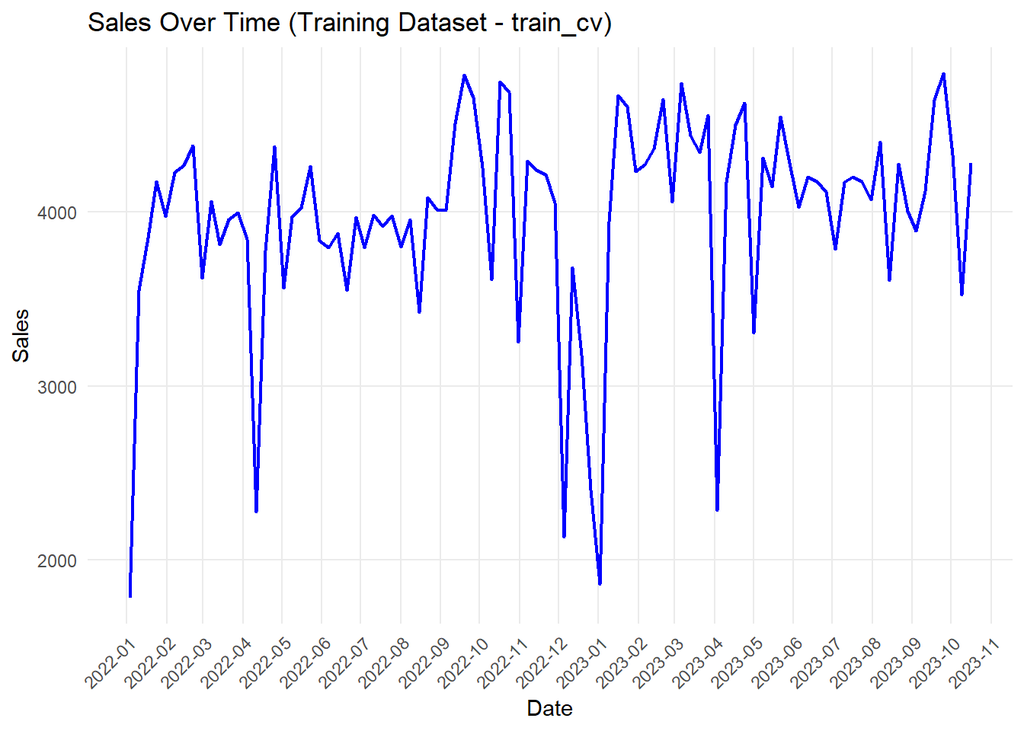

```r
# Plot Sales over time with monthly x-axis breaks
ggplot(train_cv, aes(x = Monday_date, y = Sales)) +
  geom_line(color = "blue", linewidth = 0.8) +
  scale_x_datetime(
    date_breaks = "1 month",
    date_labels = "%Y-%m"
  ) +
  labs(
    title = "Sales Over Time (Training Dataset - train_cv)",
    x = "Date",
    y = "Sales"
  ) +
  theme_minimal() +
  theme(
    axis.text.x = element_text(angle = 45, hjust = 1),
    panel.grid.minor = element_blank()
  )
```

We notice clear **cyclic patterns and seasonality** in sales:

- Sales are **consistently lower** at the first week of December and January, matching **Christmas vacation**.
- Sales are also **consistently lower** at one week in April, matching **Easter vacation** (Semana Santa).
- Sales are **consistently higher** during **September**.

These effects **explain the bimodality of the sales distribution** observed earlier in this section. Therefore, by adding features that explain these trends, we can both improve predictive power and address the bimodality issue.

There is also **some correlation between current and past sales (self-correlation)**. If sales were high last week, they are more likely to be high this week, too.

From these observations, we can guess the following aspects of the underlying business:

- During vacation (Christmas and Easter), there is either no demand or stores are closed.
- During September, demand is consistently higher, indicating the product sold may be related to school (e.g., notebooks or pencils)

These observations about the sales have the following **implications for modeling**:

- We should add **season indicator features** to help the models position themselves at each time of the year.
- We should add **vacation flag features** to indicate whether we are on vacation.
- We should add **past sales** as additional features to capture the self-correlation of this variable.

These features will be added later during feature engineering.

## Time-Series Analysis of Investments

We will now analyze each investment variable and the corresponding sales with respect to the `Monday_date` column.

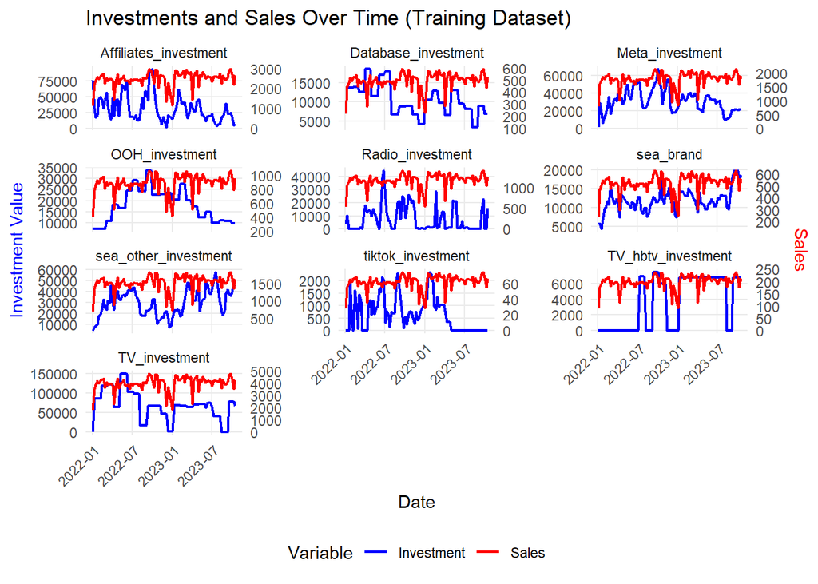

```r
# Plot each investment feature and the corresponding sales over time in train_cv
train_cv %>%
  pivot_longer(cols = all_of(investment_vars),
              names_to = "Variable",
              values_to = "Investment") %>%
  group_by(Variable) %>%
  mutate(
    # Scale sales to match investment range for each variable
    Scaled_Sales = Sales * max(Investment, na.rm = TRUE) / max(Sales, na.rm = TRUE)
  ) %>%
  ggplot() +
  geom_line(aes(x = Monday_date, y = Investment, color = "Investment"), linewidth = 0.8) +
  geom_line(aes(x = Monday_date, y = Scaled_Sales, color = "Sales"), linewidth = 0.8) +
  scale_y_continuous(
    name = "Investment Value",
    sec.axis = sec_axis(~ . * max(train_cv$Sales, na.rm = TRUE) /
                         max(train_cv %>%
                             select(all_of(investment_vars)) %>%
                             unlist() %>%
                             max(na.rm = TRUE)),
                       name = "Sales")
  ) +
  facet_wrap(~Variable, scales = "free_y", ncol = 3) +
  scale_color_manual(values = c("Investment" = "blue", "Sales" = "red")) +
  labs(title = "Investments and Sales Over Time (Training Dataset)",
       x = "Date",
       color = "Variable") +
  theme_minimal() +
  theme(
    axis.title.y.right = element_text(color = "red"),
    axis.title.y.left = element_text(color = "blue"),
    legend.position = "bottom",
    axis.text.x = element_text(angle = 45, hjust = 1),
    panel.grid.minor = element_blank()
  )
```

These time-series plots reveal:

- There is a **high correlation of current investment with past investment (self-correlation)**. If investment on a particular medium is high in one week, it is also likely to be high in the next.
- There is **no clear connection between any individual investment and sales**. In cases like Meta and SEA, both investment and sales seem to follow the same trend during some periods. However, in most cases, the individual investment by itself is not enough to explain the sales.
- There are **long periods where investment in TikTok or streaming TV ads is zero**, matching our previous observations on these features.

To understand whether some features have a **lagged effect on sales**, we will make Cross-Correlation Function (CCF) Plots, which show the correlation between each investment and sales at different lag periods. The height of bars indicates strength of correlation and red dashed lines indicate the statistical significance threshold:

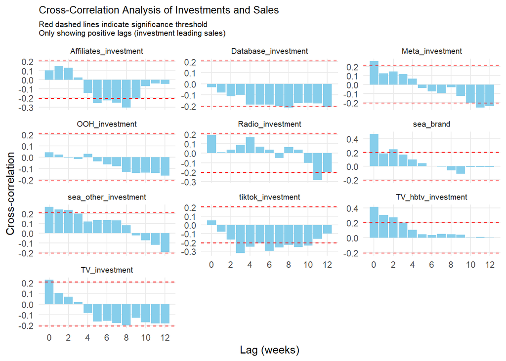

```r
# Function to compute cross-correlation analysis for positive lags only
max_lag <- 12
compute_ccf <- function(data, var_name) {
  ccf_result <- ccf(data[[var_name]], data$Sales,
                    lag.max = max_lag,
                    plot = FALSE)
  df <- data.frame(
    lag = seq(0, max_lag),  # Only positive lags
    correlation = ccf_result$acf[(max_lag + 1):(2 * max_lag + 1)]  # Corresponding correlations
  )

  return(df)
}

# Calculate CCF for each investment variable
investment_ccfs <- lapply(investment_vars, function(var) {
  ccf_df <- compute_ccf(train_cv, var)
  ccf_df$variable <- var
  return(ccf_df)
})

# Combine all results
all_ccfs <- do.call(rbind, investment_ccfs)

# Create CCF plots
ggplot(all_ccfs, aes(x = lag, y = correlation)) +
  geom_bar(stat = "identity", fill = "skyblue") +
  geom_hline(yintercept = 2/sqrt(nrow(train_cv)),
             linetype = "dashed", color = "red") +
  geom_hline(yintercept = -2/sqrt(nrow(train_cv)),
             linetype = "dashed", color = "red") +
  facet_wrap(~variable, scales = "free_y", ncol = 3) +
  labs(title = "Cross-Correlation Analysis of Investments and Sales",
       subtitle = "Red dashed lines indicate significance threshold\nOnly showing positive lags (investment leading sales)",
       x = "Lag (weeks)",
       y = "Cross-correlation") +
  theme_minimal() +
  theme(
    axis.text.x = element_text(angle = 0),
    panel.grid.minor = element_blank(),
    strip.text = element_text(size = 8),
    plot.title = element_text(size = 10),
    plot.subtitle = element_text(size = 8)
  ) +
  scale_x_continuous(breaks = seq(0, max_lag, 2))  # Show even-numbered lags
```

As we can see:

- **Most investments** have the **stronger effect at the current week (lag 0)**.
- The effects of these investments at higher lags (lag 1, 2…) likely stem from their self-correlation (observed before) rather than any real inherent lag effect.
- Other investments, particularly **search-engine advertisement (SEA) and streaming TV** (`sea_brand`, `sea_other_investment` and `TV_hbtv_investment`) also have **significant effects with lags 1 and 2**.
- Some investments, including affiliate programs, database, out-of-home ads, and TikTok, have a stronger (negative) effect at later lags. However, these are likely artifacts resulting from the use of a small dataset that do not reflect any real behavior.

Based on this analysis, we will add the lags (lag 1 and lag 2) of **SEA and streaming TV investments** during feature engineering. However, the lags of other variables did not reveal a significant effect.

## Analysis of Interaction Effects

To identify potential **interaction effects between features**, we will compute the correlation of `Sales` with each interaction (product of two features). We will compare this correlation with those of each individual feature in order to see whether the interaction is actually useful.

```r
# Function to analyze interactions between all numerical variables
analyze_variable_interactions <- function(data) {
  # Get all numerical variables except Sales
  numeric_vars <- names(data)[sapply(data, is.numeric)]
  numeric_vars <- setdiff(numeric_vars, "Sales")

  # Create all possible pairs of variables
  pairs <- combn(numeric_vars, 2, simplify = FALSE)

  # Calculate correlations for each interaction and individual variables
  interaction_cors <- do.call(rbind, lapply(pairs, function(pair) {
    var1 <- pair[1]
    var2 <- pair[2]

    # Calculate correlations
    interaction <- data[[var1]] * data[[var2]]
    cor_interaction <- cor(interaction, data$Sales, use = "complete.obs")
    cor_var1 <- cor(data[[var1]], data$Sales, use = "complete.obs")
    cor_var2 <- cor(data[[var2]], data$Sales, use = "complete.obs")

    # Return correlation info
    data.frame(
      var1 = var1,
      var2 = var2,
      cor_interaction = cor_interaction,
      cor_var1 = cor_var1,
      cor_var2 = cor_var2,
      abs_cor_interaction = abs(cor_interaction),
      # Calculate if interaction provides additional value
      improvement = abs(cor_interaction) - max(abs(cor_var1), abs(cor_var2))
    )
  }))

  # Sort by improvement in correlation and get top interactions
  top_interactions <- interaction_cors %>%
    arrange(desc(improvement)) %>%
    head(10)

  # Prepare data for plotting
  plot_data <- top_interactions %>%
    mutate(
      interaction_name = paste(var1, "*", var2),
      var1_name = paste("Variable 1:", var1),
      var2_name = paste("Variable 2:", var2)
    ) %>%
    select(interaction_name, var1_name, var2_name, cor_interaction, cor_var1, cor_var2) %>%
    tidyr::pivot_longer(
      cols = c(cor_interaction, cor_var1, cor_var2),
      names_to = "correlation_type",
      values_to = "correlation"
    ) %>%
    mutate(
      correlation_type = case_when(
        correlation_type == "cor_interaction" ~ "Interaction",
        correlation_type == "cor_var1" ~ "Variable 1",
        correlation_type == "cor_var2" ~ "Variable 2"
      )
    )

  # Create visualization
  interaction_plot <- ggplot(plot_data,
         aes(x = reorder(interaction_name, correlation * (correlation_type == "Interaction")),
             y = correlation,
             fill = correlation_type)) +
    geom_bar(stat = "identity", position = "dodge") +
    coord_flip() +
    scale_fill_manual(values = c("steelblue", "lightgreen", "lightblue")) +
    labs(
      title = "Top 10 Variable Interactions by Improvement over Individual Effects",
      subtitle = "Shows correlation with sales for interaction and individual variables",
      x = "Interaction",
      y = "Correlation with Sales",
      fill = "Type"
    ) +
    theme_minimal() +
    theme(
      legend.position = "bottom",
      plot.title = element_text(size = 11),
      plot.subtitle = element_text(size = 9)
    )

  # Return both data and plot
  list(
    top_interactions = top_interactions %>%
      arrange(desc(abs_cor_interaction)) %>%
      select(var1, var2, cor_interaction, cor_var1, cor_var2, improvement),
    plot = interaction_plot,
    plot_data = plot_data
  )
}
results <- analyze_variable_interactions(train_cv)
print(results$top_interactions)
```

```
##                     var1                 var2 cor_interaction   cor_var1
## 1                 Stores                  GBP      0.64406597 0.20998963
## 2                 Stores            sea_brand      0.47144833 0.20998963
## 3                 Stores   TV_hbtv_investment      0.41402505 0.20998963
## 4                 Stores      Meta_investment      0.27761912 0.20998963
## 5                 Stores sea_other_investment      0.27644936 0.20998963
## 6                 Stores        TV_investment      0.25073161 0.20998963
## 7  Affiliates_investment     Radio_investment      0.23466856 0.10137434
## 8  Affiliates_investment       OOH_investment      0.19435647 0.10137434
## 9  Affiliates_investment    tiktok_investment      0.14633533 0.10137434
## 10     tiktok_investment  Database_investment      0.08055372 0.05080654
##       cor_var2   improvement
## 1   0.59804681  0.0460191588
## 2   0.47485485 -0.0034065257
## 3   0.41430830 -0.0002832526
## 4   0.26077363  0.0168454958
## 5   0.26929959  0.0071497644
## 6   0.22916371  0.0215679016
## 7   0.19478956  0.0398790008
## 8   0.04151881  0.0929821267
## 9   0.05080654  0.0449609925
## 10 -0.02925677  0.0297471847
```

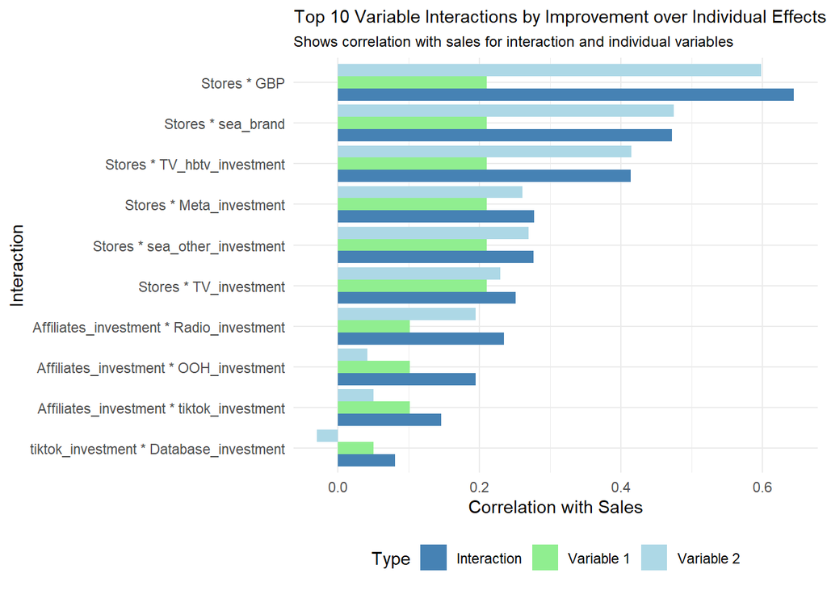

```r
print(results$plot)
```

Each of these interactions often has a **stronger effect than each of the individual features that forms it**, indicating that considering the interaction will be useful for predictive performance.

## Summary of EDA and Key Insights for Feature Engineering

Based on the Exploratory Data Analysis, here are the most critical insights and corresponding feature engineering recommendations:

Key insights:

- Several investment features (TikTok, TV streaming, Radio) contain 40-50% zeros.
- Sales show a bimodal distribution and strong seasonality (Christmas, Easter, September).
- Meta, SEA, and TV investments strongly correlate with sales, while TikTok, OOH, and affiliate investments show weak correlation.
- The logarithmic transformation makes the target more symmetrical and makes relationship more linear (higher Pearson correlation coefficient).
- The SEA and streaming TV investments have lagged effects over one and two weeks, while the other variables have a significant impact only on the current week.
- There are significant interaction effects with the number of open stores and the investment in affiliate programs.

**Feature engineering** recommendations:

- Create **binary zero-indicator variables** for investment features with many zeros.
- Add **seasonal indicators** and **vacation flags** to capture cyclical sales patterns.
- Add **lagged features** for SEA and streaming TV investments to capture the observed lagged effects.

**Model definition** recommendations:

- Add **interaction effects** between the number of open stores and several investments, as well as interactions between the investment in affiliate programs and other investments.
- *For linear models*: apply **log transformation** to both sales and investment features, `log(Sales) ~ log(features)`.
- *For machine learning models*: use the **original target and features**, `Sales ~ features`.

# Feature Engineering

## Zero Indicator Columns

In the Exploratory Data Analysis (EDA), we identified a significant number of zeros in these variables: `tiktok_investment`, `TV_hbtv_investment`, and `Radio_investment`.

For each of these variables, we will create a new column (`*_is_zero`) such that the column:

- Contains `1` if the variable is `0`.
- Contains `0` otherwise.

These indicator columns help the model capture patterns associated with periods of zero investment, potentially improving predictive performance.

```r
# Function to add zero indicator columns
add_zero_indicators <- function(data) {
  # Variables identified with significant zeros from EDA
  zero_heavy_vars <- c("tiktok_investment", "TV_hbtv_investment", "Radio_investment")

  # Create indicator columns for each variable
  for (var in zero_heavy_vars) {
    indicator_name <- paste0(var, "_is_zero")
    data[[indicator_name]] <- as.numeric(data[[var]] == 0)
  }

  return(data)
}

# Apply to all datasets
train_cv <- add_zero_indicators(train_cv)
val_cv <- add_zero_indicators(val_cv)
test_sales_data <- add_zero_indicators(test_sales_data)

glimpse(train_cv)
```

```
## Rows: 94
## Columns: 18
## $ Monday_date                <dttm> 2022-01-03, 2022-01-10, 2022-01-17, 2022-0…
## $ Sales                      <dbl> 1784, 3550, 3849, 4172, 3971, 4226, 4268, 4…
## $ Stores                     <dbl> 343, 343, 343, 343, 343, 345, 345, 345, 345…
## $ Affiliates_investment      <dbl> 75438, 31834, 16898, 21278, 45546, 49762, 4…
## $ Meta_investment            <dbl> 1507.73, 28946.82, 18356.52, 6320.86, 13617…
## $ sea_brand                  <dbl> 5612.98, 5889.35, 4363.21, 6813.07, 9635.79…
## $ sea_other_investment       <dbl> 4277.98, 7276.61, 8329.27, 10015.02, 17285.…
## $ tiktok_investment          <dbl> 0.00, 0.00, 0.00, 2053.84, 250.37, 0.00, 16…
## $ web_visits                 <dbl> 37616, 37616, 37616, 37616, 46616, 46765, 4…
## $ GBP                        <dbl> 9158, 12656, 11402, 11280, 10415, 11588, 11…
## $ Database_investment        <dbl> 13765.00, 13765.00, 13765.00, 13765.00, 137…
## $ OOH_investment             <dbl> 7276.096, 7276.096, 7276.096, 7276.096, 727…
## $ TV_hbtv_investment         <dbl> 0, 0, 0, 0, 0, 0, 0, 0, 0, 0, 0, 0, 0, 0, 0…
## $ TV_investment              <dbl> 0.00, 86647.33, 86647.33, 86647.33, 86647.3…
## $ Radio_investment           <dbl> 3990.535, 10451.400, 0.000, 0.000, 0.000, 0…
## $ tiktok_investment_is_zero  <dbl> 1, 1, 1, 0, 0, 1, 0, 0, 0, 0, 0, 1, 1, 1, 1…
## $ TV_hbtv_investment_is_zero <dbl> 1, 1, 1, 1, 1, 1, 1, 1, 1, 1, 1, 1, 1, 1, 1…
## $ Radio_investment_is_zero   <dbl> 0, 0, 1, 1, 1, 1, 1, 1, 1, 1, 0, 1, 0, 0, 0…
```

```r
glimpse(val_cv)
```

```
## Rows: 23
## Columns: 18
## $ Monday_date                <dttm> 2023-10-23, 2023-10-30, 2023-11-06, 2023-1…
## $ Sales                      <dbl> 4351, 3279, 4179, 4381, 4257, 4247, 2052, 3…
## $ Stores                     <dbl> 383, 383, 384, 384, 384, 384, 384, 384, 384…
## $ Affiliates_investment      <dbl> 3679.2, 3855.0, 3087.6, 1998.0, 3492.0, 223…
## $ Meta_investment            <dbl> 21254.190, 20140.110, 15115.020, 9242.110, …
## $ sea_brand                  <dbl> 21254.63, 17946.89, 15675.39, 9915.01, 1189…
## $ sea_other_investment       <dbl> 52180.99, 45851.55, 49659.03, 33437.32, 298…
## $ tiktok_investment          <dbl> 0, 0, 0, 0, 0, 0, 0, 0, 0, 0, 0, 0, 0, 0, 0…
## $ web_visits                 <dbl> 97932, 87262, 92407, 86389, 86859, 88816, 7…
## $ GBP                        <dbl> 10825, 9686, 11467, 11306, 12080, 11125, 82…
## $ Database_investment        <dbl> 6847.135, 6847.135, 9806.250, 9806.250, 980…
## $ OOH_investment             <dbl> 9592.274, 9592.274, 11714.540, 11714.540, 1…
## $ TV_hbtv_investment         <dbl> 6818.182, 6818.182, 6818.182, 6818.182, 681…
## $ TV_investment              <dbl> 67666.75, 67666.75, 67666.75, 66618.85, 666…
## $ Radio_investment           <dbl> 52257.001, 5700.764, 0.000, 0.000, 0.000, 0…
## $ tiktok_investment_is_zero  <dbl> 1, 1, 1, 1, 1, 1, 1, 1, 1, 1, 1, 1, 1, 1, 1…
## $ TV_hbtv_investment_is_zero <dbl> 0, 0, 0, 0, 0, 0, 1, 1, 1, 1, 1, 1, 0, 0, 0…
## $ Radio_investment_is_zero   <dbl> 0, 0, 1, 1, 1, 1, 1, 1, 1, 1, 1, 1, 1, 1, 1…
```

```r
glimpse(test_sales_data)
```

```
## Rows: 25
## Columns: 18
## $ Monday_date                <dttm> 2024-04-01, 2024-04-08, 2024-04-15, 2024-0…
## $ Sales                      <dbl> NA, NA, NA, NA, NA, NA, NA, NA, NA, NA, NA,…
## $ Stores                     <dbl> 387, 387, 387, 387, 387, 387, 387, 388, 388…
## $ Affiliates_investment      <dbl> 6117.0, 11912.4, 9560.8, 2924.9, 8721.6, 65…
## $ Meta_investment            <dbl> 26999.78, 25441.90, 25334.83, 27426.23, 265…
## $ sea_brand                  <dbl> 18822.06, 19424.21, 29562.08, 15634.89, 291…
## $ sea_other_investment       <dbl> 76230.43, 78370.29, 73387.79, 44404.67, 752…
## $ tiktok_investment          <dbl> 0, 0, 0, 0, 0, 0, 0, 0, 0, 0, 0, 0, 0, 0, 0…
## $ web_visits                 <dbl> 116425, 122924, 125179, 113752, 122473, 129…
## $ GBP                        <dbl> 10509, 10778, 11416, 11280, 8548, 10433, 98…
## $ Database_investment        <dbl> 7350.0, 7350.0, 7350.0, 7350.0, 7350.0, 132…
## $ OOH_investment             <dbl> 15260.062, 15260.062, 15260.062, 16383.425,…
## $ TV_hbtv_investment         <dbl> 6774.194, 6774.194, 6774.194, 6774.194, 677…
## $ TV_investment              <dbl> 75717.51, 75717.51, 71819.29, 71819.29, 718…
## $ Radio_investment           <dbl> 29975.44, 29975.44, 34237.99, 47811.20, 214…
## $ tiktok_investment_is_zero  <dbl> 1, 1, 1, 1, 1, 1, 1, 1, 1, 1, 1, 1, 1, 1, 1…
## $ TV_hbtv_investment_is_zero <dbl> 0, 0, 0, 0, 0, 0, 0, 0, 0, 0, 0, 0, 0, 0, 0…
## $ Radio_investment_is_zero   <dbl> 0, 0, 0, 0, 0, 1, 0, 0, 0, 0, 0, 0, 0, 1, 1…
```

## Seasonal Indicators

Based on our observations of the sales time series, we will add **seasonal indicators** to help capture the observed time-dependent patterns in the data:

- **Annual Cycle Indicators (365.25 days)**: These capture yearly patterns, like Christmas sales or summer trends. One full cycle completes every year.
  - seasonal_annual_sin = $\sin(\frac{2\pi \cdot \text{day}}{365.25})$
  - seasonal_annual_cos = $\cos(\frac{2\pi \cdot \text{day}}{365.25})$
- **Semi-annual Cycle Indicators (182.625 days)**: These complete two cycles per year, helping capture patterns that repeat twice yearly, like spring/fall transitions.
  - seasonal_semiannual_sin = $\sin(\frac{4\pi \cdot \text{day}}{365.25})$
  - seasonal_semiannual_cos = $\cos(\frac{4\pi \cdot \text{day}}{365.25})$
- **Quarterly Cycle Indicators (91.3125 days)**: These complete four cycles per year, useful for capturing seasonal patterns within each quarter.
  - seasonal_quarterly_sin = $\sin(\frac{8\pi \cdot \text{day}}{365.25})$
  - seasonal_quarterly_cos = $\cos(\frac{8\pi \cdot \text{day}}{365.25})$
- **Monthly Cycle Indicators (30.4375 days)**: These complete twelve cycles per year, capturing patterns that repeat monthly.
  - seasonal_monthly_sin = $\sin(\frac{24\pi \cdot \text{day}}{365.25})$
  - seasonal_monthly_cos = $\cos(\frac{24\pi \cdot \text{day}}{365.25})$

In each case, using both sine and cosine will allow our models to capture patterns regardless of when they start in the cycle.

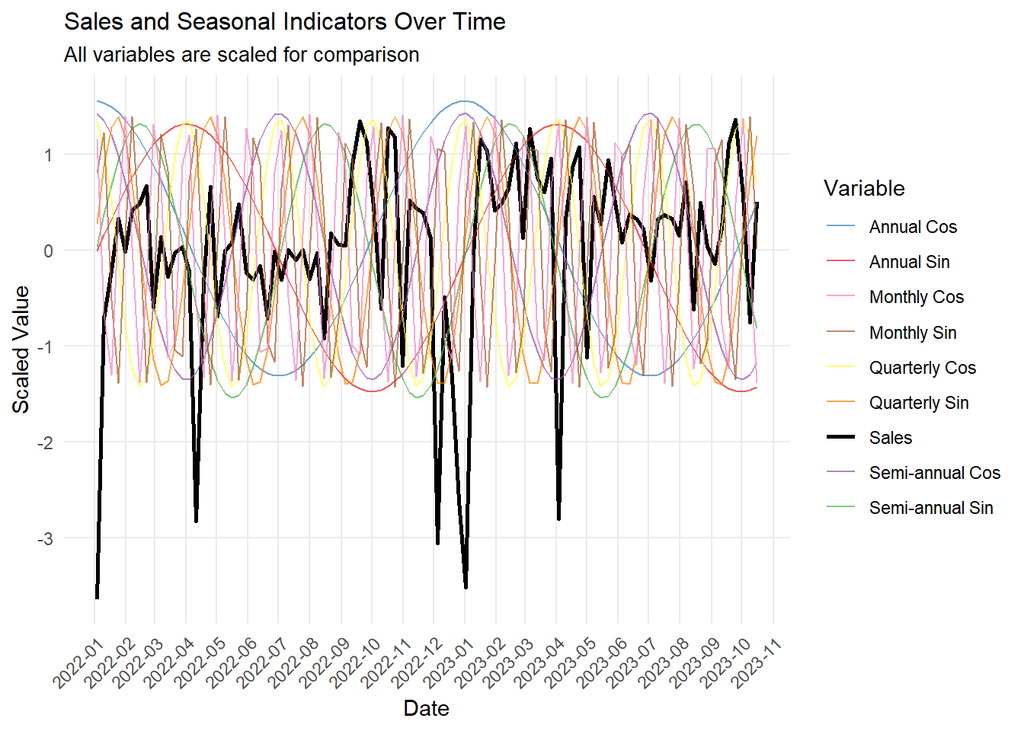

```r
# Function to add seasonal indicators
add_seasonal_indicators <- function(data) {
  # Convert dates to numeric (days since epoch)
  data <- data %>%
    mutate(
      # Get day of year (1-366)
      day_of_year = as.numeric(format(Monday_date, "%j")),

      # Create seasonal features with different frequencies
      # Annual cycle (365.25 days)
      seasonal_annual_sin = sin(2 * pi * day_of_year / 365.25),
      seasonal_annual_cos = cos(2 * pi * day_of_year / 365.25),

      # Semi-annual cycle (182.625 days)
      seasonal_semiannual_sin = sin(4 * pi * day_of_year / 365.25),
      seasonal_semiannual_cos = cos(4 * pi * day_of_year / 365.25),

      # Quarterly cycle (91.3125 days)
      seasonal_quarterly_sin = sin(8 * pi * day_of_year / 365.25),
      seasonal_quarterly_cos = cos(8 * pi * day_of_year / 365.25),

      # Monthly cycle (30.4375 days)
      seasonal_monthly_sin = sin(24 * pi * day_of_year / 365.25),
      seasonal_monthly_cos = cos(24 * pi * day_of_year / 365.25)
    ) %>%
    select(-day_of_year)  # Remove temporary column

  return(data)
}

# Apply to all datasets
train_cv <- add_seasonal_indicators(train_cv)
val_cv <- add_seasonal_indicators(val_cv)
test_sales_data <- add_seasonal_indicators(test_sales_data)

# Create visualization comparing sales with seasonal indicators
# First, scale all variables to be comparable
train_cv_plot <- train_cv %>%
  select(Monday_date, Sales, starts_with("seasonal")) %>%
  mutate(across(c(Sales, starts_with("seasonal")),
                ~scale(.) %>% as.vector(),
                .names = "{.col}_scaled"))

# Create the plot
seasonal_plot <- ggplot(train_cv_plot) +
  # Base layer with sales
  geom_line(aes(x = Monday_date, y = Sales_scaled, color = "Sales"),
            linewidth = 1) +

  # Add annual cycle
  geom_line(aes(x = Monday_date, y = seasonal_annual_sin_scaled,
                color = "Annual Sin"), alpha = 0.7) +
  geom_line(aes(x = Monday_date, y = seasonal_annual_cos_scaled,
                color = "Annual Cos"), alpha = 0.7) +

  # Add semi-annual cycle
  geom_line(aes(x = Monday_date, y = seasonal_semiannual_sin_scaled,
                color = "Semi-annual Sin"), alpha = 0.7) +
  geom_line(aes(x = Monday_date, y = seasonal_semiannual_cos_scaled,
                color = "Semi-annual Cos"), alpha = 0.7) +

  # Add quarterly cycle
  geom_line(aes(x = Monday_date, y = seasonal_quarterly_sin_scaled,
                color = "Quarterly Sin"), alpha = 0.7) +
  geom_line(aes(x = Monday_date, y = seasonal_quarterly_cos_scaled,
                color = "Quarterly Cos"), alpha = 0.7) +

  # Add monthly cycle
  geom_line(aes(x = Monday_date, y = seasonal_monthly_sin_scaled,
                color = "Monthly Sin"), alpha = 0.7) +
  geom_line(aes(x = Monday_date, y = seasonal_monthly_cos_scaled,
                color = "Monthly Cos"), alpha = 0.7) +

  # Customize the plot
  scale_x_datetime(date_breaks = "1 month", date_labels = "%Y-%m") +
  scale_color_manual(values = c(
    "Sales" = "black",
    "Annual Sin" = "#E41A1C",
    "Annual Cos" = "#377EB8",
    "Semi-annual Sin" = "#4DAF4A",
    "Semi-annual Cos" = "#984EA3",
    "Quarterly Sin" = "#FF7F00",
    "Quarterly Cos" = "#FFFF33",
    "Monthly Sin" = "#A65628",
    "Monthly Cos" = "#F781BF"
  )) +
  labs(
    title = "Sales and Seasonal Indicators Over Time",
    subtitle = "All variables are scaled for comparison",
    x = "Date",
    y = "Scaled Value",
    color = "Variable"
  ) +
  theme_minimal() +
  theme(
    legend.position = "right",
    axis.text.x = element_text(angle = 45, hjust = 1),
    panel.grid.minor = element_blank(),
    plot.title = element_text(size = 12),
    plot.subtitle = element_text(size = 10)
  )

# Display the plot
print(seasonal_plot)
```

We will check the usefulness of these new features by **plotting their correlation with sales and assessing their significance**:

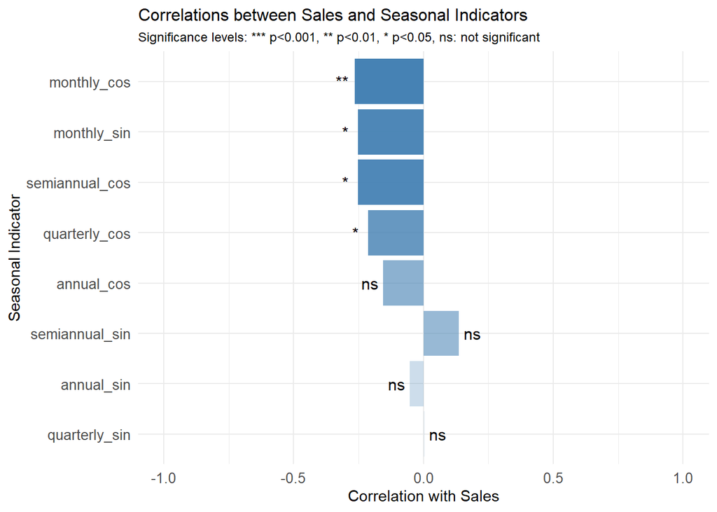

```r
# Print summary of correlations between sales and seasonal indicators
correlations <- cor(train_cv %>%
                     select(Sales, starts_with("seasonal"))) %>%
  as.data.frame() %>%
  select(Sales) %>%
  arrange(desc(abs(Sales))) %>%
  filter(row.names(.) != "Sales")

# Calculate correlations and significance
correlation_data <- data.frame(
  feature = character(),
  correlation = numeric(),
  p_value = numeric()
)

for (col in names(train_cv)[startsWith(names(train_cv), "seasonal")]) {
  cor_test <- cor.test(train_cv$Sales, train_cv[[col]])
  correlation_data <- rbind(correlation_data, data.frame(
    feature = col,
    correlation = cor_test$estimate,
    p_value = cor_test$p.value
  ))
}

# Create significance labels
correlation_data <- correlation_data %>%
  mutate(
    significance = case_when(
      p_value < 0.001 ~ "***",
      p_value < 0.01 ~ "**",
      p_value < 0.05 ~ "*",
      TRUE ~ "ns"
    ),
    feature = gsub("seasonal_", "", feature)  # Clean feature names
  )

# Create bar plot
correlation_plot <- ggplot(correlation_data,
       aes(x = reorder(feature, abs(correlation)), y = correlation)) +
  geom_bar(stat = "identity", fill = "steelblue",
           aes(alpha = abs(correlation))) +
  geom_text(aes(label = significance, y = correlation +
                sign(correlation) * 0.05),
            size = 4) +
  coord_flip() +
  labs(
    title = "Correlations between Sales and Seasonal Indicators",
    subtitle = "Significance levels: *** p<0.001, ** p<0.01, * p<0.05, ns: not significant",
    x = "Seasonal Indicator",
    y = "Correlation with Sales"
  ) +
  theme_minimal() +
  theme(
    legend.position = "none",
    axis.text = element_text(size = 10),
    plot.title = element_text(size = 12),
    plot.subtitle = element_text(size = 9)
  ) +
  scale_y_continuous(limits = c(-1, 1))

# Print correlation plot
print(correlation_plot)
```

As we can see, **half of the variables have a noticeable and significant correlation**, with the absolute correlation higher than 0.2 (noticeable) and the p-value below 0.05 (significant).

## Vacation Flags

Given our observations on how much sales drop during vacation, we will add two binary indicators:

- `is_christmas_vacation`: Set to 1 for December 25th to January 8th (typical Christmas vacation).
- `is_easter_vacation`: Set to 1 for Holy Week (Semana Santa, the week before Easter Sunday). We will use the Meeus/Jones/Butcher algorithm to calculate Easter Sunday for each year (since it’s a moving holiday). However, we will exclude 2024-03-25 from Eastern period since the sales at this date do not follow the expected trend.

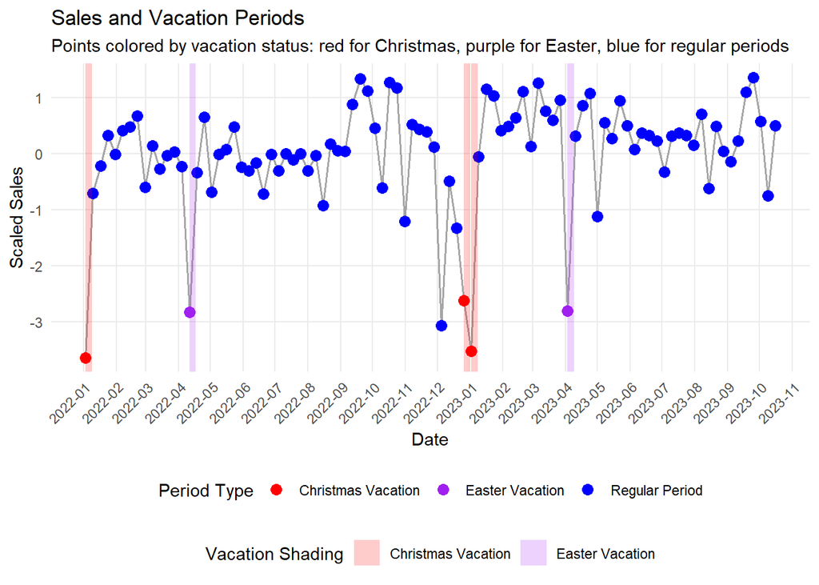

```r
# Function to add vacation flags
add_vacation_flags <- function(data) {
  data <- data %>%
    mutate(
      # Extract month and day for easier comparison
      month = as.numeric(format(Monday_date, "%m")),
      day = as.numeric(format(Monday_date, "%d")),

      # Christmas vacation flag (typically December 25 - January 8 in Spain)
      is_christmas_vacation = case_when(
        (month == 12 & day >= 25) | (month == 1 & day <= 8) ~ 1,
        TRUE ~ 0
      ),

      # Easter vacation flag (Semana Santa)
      # Since Easter is a moving holiday, we need to calculate it for each year
      year = as.numeric(format(Monday_date, "%Y"))
    )

  # Function to get Easter Sunday date
  # Meeus/Jones/Butcher algorithm
  get_easter_sunday <- function(year) {
    a <- year %% 19
    b <- floor(year / 100)
    c <- year %% 100
    d <- floor(b / 4)
    e <- b %% 4
    f <- floor((b + 8) / 25)
    g <- floor((b - f + 1) / 3)
    h <- (19 * a + b - d - g + 15) %% 30
    i <- floor(c / 4)
    k <- c %% 4
    l <- (32 + 2 * e + 2 * i - h - k) %% 7
    m <- floor((a + 11 * h + 22 * l) / 451)
    month <- floor((h + l - 7 * m + 114) / 31)
    day <- ((h + l - 7 * m + 114) %% 31) + 1
    return(as.Date(sprintf("%d-%02d-%02d", year, month, day)))
  }

  # Get unique years in the dataset
  years <- unique(data$year)

  # Create Easter dates lookup
  easter_dates <- sapply(years, get_easter_sunday)
  names(easter_dates) <- years

  # Add Easter vacation flag (typically the week before Easter Sunday in Spain)
  data <- data %>%
    rowwise() %>%
    mutate(
      easter_sunday = as.Date(easter_dates[as.character(year)]),
      easter_week_start = easter_sunday - 7,
      # Check if Monday_date falls within Easter week, excluding March 25, 2024
      is_easter_vacation = case_when(
        as.Date(Monday_date) == as.Date("2024-03-25") ~ 0,  # Exclude specific date
        as.Date(Monday_date) >= easter_week_start &
        as.Date(Monday_date) <= easter_sunday ~ 1,
        TRUE ~ 0
      )
    ) %>%
    ungroup() %>%
    select(-month, -day, -year, -easter_sunday, -easter_week_start)

  return(data)
}

# Apply to all datasets
train_cv <- add_vacation_flags(train_cv)
val_cv <- add_vacation_flags(val_cv)
test_sales_data <- add_vacation_flags(test_sales_data)

# Visualize the impact of vacation flags on sales
train_cv_vacation <- train_cv %>%
  mutate(vacation_status = case_when(
    is_christmas_vacation == 1 ~ "Christmas Vacation",
    is_easter_vacation == 1 ~ "Easter Vacation",
    TRUE ~ "Regular Period"
  ))
vacation_plot <- ggplot(train_cv_vacation, aes(x = Monday_date)) +
  # Plot sales line
  geom_line(aes(y = scale(Sales)), color = "gray50", linewidth = 0.6, alpha = 0.7) +

  # Add points for each observation, colored by vacation status
  geom_point(aes(y = scale(Sales), color = vacation_status), size = 3) +

  # Add shaded regions for vacations
  geom_rect(data = train_cv %>% filter(is_christmas_vacation == 1),
            aes(xmin = Monday_date,
                xmax = Monday_date + days(6),
                ymin = -Inf,
                ymax = Inf,
                fill = "Christmas Vacation"),
            alpha = 0.2) +

  geom_rect(data = train_cv %>% filter(is_easter_vacation == 1),
            aes(xmin = Monday_date,
                xmax = Monday_date + days(6),
                ymin = -Inf,
                ymax = Inf,
                fill = "Easter Vacation"),
            alpha = 0.2) +

  scale_x_datetime(date_breaks = "1 month",
                  date_labels = "%Y-%m") +
  scale_color_manual(values = c(
    "Regular Period" = "blue",
    "Christmas Vacation" = "red",
    "Easter Vacation" = "purple"
  )) +
  scale_fill_manual(values = c(
    "Christmas Vacation" = "red",
    "Easter Vacation" = "purple"
  )) +
  labs(
    title = "Sales and Vacation Periods",
    subtitle = "Points colored by vacation status: red for Christmas, purple for Easter, blue for regular periods",
    x = "Date",
    y = "Scaled Sales",
    color = "Period Type",
    fill = "Vacation Shading"
  ) +
  theme_minimal() +
  theme(
    legend.position = "bottom",
    axis.text.x = element_text(angle = 45, hjust = 1),
    panel.grid.minor = element_blank(),
    legend.box = "vertical"
  ) +
  guides(
    color = guide_legend(order = 1),
    fill = guide_legend(order = 2)
  )
print(vacation_plot)
```

As we can see in the graph, **these vacation flags help explain the noticeable drops in sales**. We can check this with the following summary statistics:

```r
# Print summary statistics
cat("\nSummary of vacation periods in training set:\n")
```

```
##
## Summary of vacation periods in training set:
```

```r
train_cv %>%
  summarise(
    total_weeks = n(),
    christmas_weeks = sum(is_christmas_vacation),
    easter_weeks = sum(is_easter_vacation),
    pct_christmas = mean(is_christmas_vacation) * 100,
    pct_easter = mean(is_easter_vacation) * 100
  ) %>%
  print()
```

```
## # A tibble: 1 × 5
##   total_weeks christmas_weeks easter_weeks pct_christmas pct_easter
##         <int>           <dbl>        <dbl>         <dbl>      <dbl>
## 1          94               3            2          3.19       2.13
```

```r
# Calculate average sales during vacation vs non-vacation periods
cat("\nAverage sales by period type:\n")
```

```
##
## Average sales by period type:
```

```r
train_cv %>%
  mutate(
    period_type = case_when(
      is_christmas_vacation == 1 ~ "Christmas Vacation",
      is_easter_vacation == 1 ~ "Easter Vacation",
      TRUE ~ "Normal Period"
    )
  ) %>%
  group_by(period_type) %>%
  summarise(
    avg_sales = mean(Sales),
    std_sales = sd(Sales),
    n_weeks = n()
  ) %>%
  print()
```

```
## # A tibble: 3 × 4
##   period_type        avg_sales std_sales n_weeks
##   <chr>                  <dbl>     <dbl>   <int>
## 1 Christmas Vacation     2016.    338.         3
## 2 Easter Vacation        2282       8.49       2
## 3 Normal Period          4083.    416.        89
```

As we can see, adding these features will not only improve predictive performance, but also **address the bimodality previously observed with sales**, with one small peak around 2000 (corresponding to vacation) and another peak around 4000 (corresponding to normal periods).

## Lagged Features

In our Exploratory Data Analysis, we have observed that the following variables have a lagged effect on sales: `sea_brand`, `sea_other_investment`, and `TV_hbtv_investment`. When lagged 1 or 2 weeks, the lags of these features showed significant correlations with the target.

To include these features without introducing unnecessary NAs, we will add them to the full dataset and then copy the corresponding columns to the training CV, validation and testing sets.

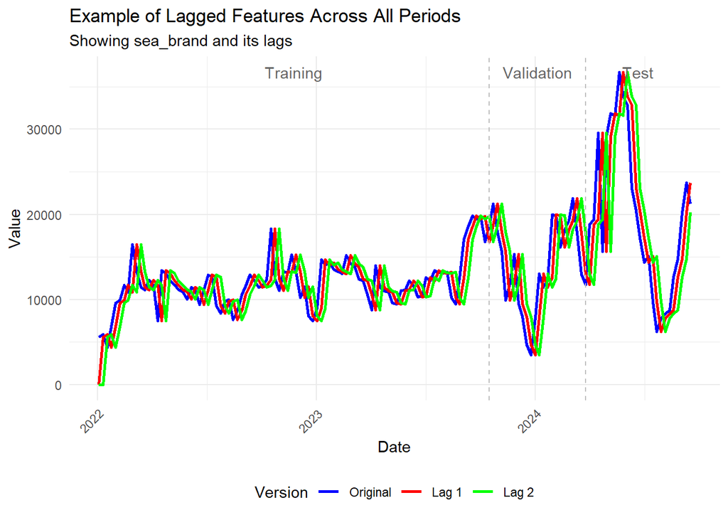

```r
# Variables identified with significant lag effects from EDA
lag_vars <- c("sea_brand", "sea_other_investment", "TV_hbtv_investment")

# Function to add lagged features
add_lagged_features <- function(data) {

  # Ensure data is ordered by date before creating lags
  data <- data %>%
    arrange(Monday_date)

  # Add lag 1 and lag 2 for each variable
  for (var in lag_vars) {
    # Create column names for lags
    lag1_name <- paste0(var, "_lag1")
    lag2_name <- paste0(var, "_lag2")

    # Add lagged columns
    data <- data %>%
      mutate(
        !!lag1_name := lag(!!sym(var), 1),
        !!lag2_name := lag(!!sym(var), 2)
      )
  }

  return(data)
}

# First apply to complete dataset
sales_data_with_lags <- add_lagged_features(sales_data)

# Replace NAs with zeros only at the beginning (first 2 rows of full dataset)
sales_data_with_lags <- sales_data_with_lags %>%
  mutate(across(ends_with(c("_lag1", "_lag2")), ~replace_na(., 0)))

# Now split the data maintaining the lagged columns
# Get the lagged column names
lag_cols <- names(sales_data_with_lags)[grep("_lag[12]$", names(sales_data_with_lags))]

# Add lagged columns to each dataset
train_cv <- train_cv %>%
  left_join(sales_data_with_lags %>%
              select(Monday_date, all_of(lag_cols)),
            by = "Monday_date")

val_cv <- val_cv %>%
  left_join(sales_data_with_lags %>%
              select(Monday_date, all_of(lag_cols)),
            by = "Monday_date")

test_sales_data <- test_sales_data %>%
  left_join(sales_data_with_lags %>%
              select(Monday_date, all_of(lag_cols)),
            by = "Monday_date")

# Create visualization of original and lagged features across all periods
example_var <- "sea_brand"

lag_plot <- sales_data_with_lags %>%
  select(Monday_date,
         !!example_var,
         paste0(example_var, "_lag1"),
         paste0(example_var, "_lag2")) %>%
  pivot_longer(cols = -Monday_date,
               names_to = "variable",
               values_to = "value") %>%
  mutate(
    variable = factor(variable,
                     levels = c(example_var,
                              paste0(example_var, "_lag1"),
                              paste0(example_var, "_lag2")),
                     labels = c("Original", "Lag 1", "Lag 2")),
    # Add period information for visualization
    period = case_when(
      Monday_date <= max(train_cv$Monday_date) ~ "Training",
      Monday_date <= max(val_cv$Monday_date) ~ "Validation",
      TRUE ~ "Test"
    )
  ) %>%
  ggplot(aes(x = Monday_date, y = value, color = variable)) +
  geom_line(linewidth = 1) +
  geom_vline(xintercept = as.numeric(max(train_cv$Monday_date)),
             linetype = "dashed", color = "gray") +
  geom_vline(xintercept = as.numeric(max(val_cv$Monday_date)),
             linetype = "dashed", color = "gray") +
  annotate("text",
           x = c(mean(train_cv$Monday_date),
                 mean(c(max(train_cv$Monday_date), max(val_cv$Monday_date))),
                 mean(c(max(val_cv$Monday_date), max(test_sales_data$Monday_date)))),
           y = max(sales_data_with_lags[[example_var]]),
           label = c("Training", "Validation", "Test"),
           color = "gray40") +
  scale_color_manual(values = c("Original" = "blue",
                               "Lag 1" = "red",
                               "Lag 2" = "green")) +
  labs(
    title = "Example of Lagged Features Across All Periods",
    subtitle = paste("Showing", example_var, "and its lags"),
    x = "Date",
    y = "Value",
    color = "Version"
  ) +
  theme_minimal() +
  theme(
    legend.position = "bottom",
    axis.text.x = element_text(angle = 45, hjust = 1)
  )

# Display the plot
print(lag_plot)
```

## Summary of Feature Engineering

These new features address the bimodal distribution of sales and capture important temporal patterns in the data.

# Model Formula Definition

Based on our Exploratory Data Analysis (EDA) and feature engineering, we now define **two distinct model formulas**:

- One for **linear models** (including Elastic Net).
- Another for **machine learning approaches** (Random Forest, XGBoost).

The key distinction lies in the transformation of variables: linear models require log transformations to meet linearity assumptions and handle skewed distributions, while machine learning models can work with the original scales.

Both formulas will incorporate:

- The **zero indicators, seasonality features, vacations flags, and lagged investments** introduced during feature engineering.
- The **interaction effects** that were found to be significant during EDA:
  - `Stores` with `GBP`, `sea_brand`, `sea_other_investment`, `TV_hbtv_investment`, `TV_investment` and `Meta_investment`.
  - `Affiliates_investment` with `Radio_investment`, `OOH_investment`, and `tiktok_investment`.

- `formula_ml_no_seasonal`: exclude the seasonal indicators.
- `formula_ml_no_vacation`: exclude the vacation flags.

```r
# Define variables that should be log-transformed for linear models
log_vars <- c(
  "Affiliates_investment",
  "Meta_investment",
  "sea_brand",
  "sea_other_investment",
  "tiktok_investment",
  "Database_investment",
  "OOH_investment",
  "TV_hbtv_investment",
  "TV_investment",
  "Radio_investment",
  # Not investment features (but similar scale)
  "GBP",
  "web_visits",
  # Lagged features (already defined with lag suffix)
  "sea_brand_lag1",
  "sea_brand_lag2",
  "sea_other_investment_lag1",
  "sea_other_investment_lag2",
  "TV_hbtv_investment_lag1",
  "TV_hbtv_investment_lag2"
)

# Define variables that should not be log-transformed
# These include: stores, zero indicators, vacation indicators
non_log_vars_base <- c(
  "Stores",
  # Zero indicators
  "tiktok_investment_is_zero",
  "TV_hbtv_investment_is_zero",
  "Radio_investment_is_zero"
)

# Seasonal indicators
seasonal_vars <- c(
  "seasonal_annual_sin",
  "seasonal_annual_cos",
  "seasonal_semiannual_sin",
  "seasonal_semiannual_cos",
  "seasonal_quarterly_sin",
  "seasonal_quarterly_cos",
  "seasonal_monthly_sin",
  "seasonal_monthly_cos"
)

# Vacation indicators
vacation_vars <- c(
  "is_christmas_vacation",
  "is_easter_vacation"
)

# Combine all non-log variables for linear formula
non_log_vars <- c(non_log_vars_base, seasonal_vars, vacation_vars)

# Create interaction terms for stores
stores_interactions <- c(
  "Stores:GBP",
  "Stores:sea_brand",
  "Stores:sea_other_investment",
  "Stores:TV_hbtv_investment",
  "Stores:TV_investment",
  "Stores:Meta_investment"
)

# Create interaction terms for affiliates
affiliates_interactions <- c(
  "Affiliates_investment:Radio_investment",
  "Affiliates_investment:OOH_investment",
  "Affiliates_investment:tiktok_investment"
)

# Linear model formula with log transformations
formula_linear <- as.formula(paste(
  "log(Sales) ~",
  # Add log-transformed investment variables
  paste(paste0("log(", log_vars, " + 1)"), collapse = " + "),
  "+",
  # Add non-transformed variables
  paste(non_log_vars, collapse = " + "),
  "+",
  # Add interactions (with log transformations for investment variables)
  paste("Stores:log(GBP + 1)",
        "Stores:log(sea_brand + 1)",
        "Stores:log(sea_other_investment + 1)",
        "Stores:log(TV_hbtv_investment + 1)",
        "Stores:log(TV_investment + 1)",
        "Stores:log(Meta_investment + 1)",
        "log(Affiliates_investment + 1):log(Radio_investment + 1)",
        "log(Affiliates_investment + 1):log(OOH_investment + 1)",
        "log(Affiliates_investment + 1):log(tiktok_investment + 1)",
        sep = " + ")
))

# Original ML formula (with all variables)
formula_ml <- as.formula(paste(
  "Sales ~",
  # Add all investment variables (no transformation)
  paste(log_vars, collapse = " + "),
  "+",
  # Add all other variables
  paste(c(non_log_vars_base, seasonal_vars, vacation_vars), collapse = " + "),
  "+",
  # Add interactions (no transformations)
  paste(stores_interactions, collapse = " + "),
  "+",
  paste(affiliates_interactions, collapse = " + ")
))

# ML formula without seasonality indicators
formula_ml_no_seasonal <- as.formula(paste(
  "Sales ~",
  # Add all investment variables (no transformation)
  paste(log_vars, collapse = " + "),
  "+",
  # Add base variables and vacation indicators (no seasonality)
  paste(c(non_log_vars_base, vacation_vars), collapse = " + "),
  "+",
  # Add interactions (no transformations)
  paste(stores_interactions, collapse = " + "),
  "+",
  paste(affiliates_interactions, collapse = " + ")
))

# ML formula without vacation indicators
formula_ml_no_vacation <- as.formula(paste(
  "Sales ~",
  # Add all investment variables (no transformation)
  paste(log_vars, collapse = " + "),
  "+",
  # Add all other variables
  paste(c(non_log_vars_base, seasonal_vars), collapse = " + "),
  "+",
  # Add interactions (no transformations)
  paste(stores_interactions, collapse = " + "),
  "+",
  paste(affiliates_interactions, collapse = " + ")
))

# Print all formulas
cat("Linear Model Formula:\n")
```

```
## Linear Model Formula:
```

```r
print(formula_linear)
```

```
## log(Sales) ~ log(Affiliates_investment + 1) + log(Meta_investment +
##     1) + log(sea_brand + 1) + log(sea_other_investment + 1) +
##     log(tiktok_investment + 1) + log(Database_investment + 1) +
##     log(OOH_investment + 1) + log(TV_hbtv_investment + 1) + log(TV_investment +
##     1) + log(Radio_investment + 1) + log(GBP + 1) + log(web_visits +
##     1) + log(sea_brand_lag1 + 1) + log(sea_brand_lag2 + 1) +
##     log(sea_other_investment_lag1 + 1) + log(sea_other_investment_lag2 +
##     1) + log(TV_hbtv_investment_lag1 + 1) + log(TV_hbtv_investment_lag2 +
##     1) + Stores + tiktok_investment_is_zero + TV_hbtv_investment_is_zero +
##     Radio_investment_is_zero + seasonal_annual_sin + seasonal_annual_cos +
##     seasonal_semiannual_sin + seasonal_semiannual_cos + seasonal_quarterly_sin +
##     seasonal_quarterly_cos + seasonal_monthly_sin + seasonal_monthly_cos +
##     is_christmas_vacation + is_easter_vacation + Stores:log(GBP +
##     1) + Stores:log(sea_brand + 1) + Stores:log(sea_other_investment +
##     1) + Stores:log(TV_hbtv_investment + 1) + Stores:log(TV_investment +
##     1) + Stores:log(Meta_investment + 1) + log(Affiliates_investment +
##     1):log(Radio_investment + 1) + log(Affiliates_investment +
##     1):log(OOH_investment + 1) + log(Affiliates_investment +
##     1):log(tiktok_investment + 1)
```

```r
cat("\nOriginal ML Formula:\n")
```

```
##
## Original ML Formula:
```

```r
print(formula_ml)
```

```
## Sales ~ Affiliates_investment + Meta_investment + sea_brand +
##     sea_other_investment + tiktok_investment + Database_investment +
##     OOH_investment + TV_hbtv_investment + TV_investment + Radio_investment +
##     GBP + web_visits + sea_brand_lag1 + sea_brand_lag2 + sea_other_investment_lag1 +
##     sea_other_investment_lag2 + TV_hbtv_investment_lag1 + TV_hbtv_investment_lag2 +
##     Stores + tiktok_investment_is_zero + TV_hbtv_investment_is_zero +
##     Radio_investment_is_zero + seasonal_annual_sin + seasonal_annual_cos +
##     seasonal_semiannual_sin + seasonal_semiannual_cos + seasonal_quarterly_sin +
##     seasonal_quarterly_cos + seasonal_monthly_sin + seasonal_monthly_cos +
##     is_christmas_vacation + is_easter_vacation + Stores:GBP +
##     Stores:sea_brand + Stores:sea_other_investment + Stores:TV_hbtv_investment +
##     Stores:TV_investment + Stores:Meta_investment + Affiliates_investment:Radio_investment +
##     Affiliates_investment:OOH_investment + Affiliates_investment:tiktok_investment
```

```r
cat("\nML Formula without Seasonality:\n")
```

```
##
## ML Formula without Seasonality:
```

```r
print(formula_ml_no_seasonal)
```

```
## Sales ~ Affiliates_investment + Meta_investment + sea_brand +
##     sea_other_investment + tiktok_investment + Database_investment +
##     OOH_investment + TV_hbtv_investment + TV_investment + Radio_investment +
##     GBP + web_visits + sea_brand_lag1 + sea_brand_lag2 + sea_other_investment_lag1 +
##     sea_other_investment_lag2 + TV_hbtv_investment_lag1 + TV_hbtv_investment_lag2 +
##     Stores + tiktok_investment_is_zero + TV_hbtv_investment_is_zero +
##     Radio_investment_is_zero + is_christmas_vacation + is_easter_vacation +
##     Stores:GBP + Stores:sea_brand + Stores:sea_other_investment +
##     Stores:TV_hbtv_investment + Stores:TV_investment + Stores:Meta_investment +
##     Affiliates_investment:Radio_investment + Affiliates_investment:OOH_investment +
##     Affiliates_investment:tiktok_investment
```

```r
cat("\nML Formula without Vacation:\n")
```

```
##
## ML Formula without Vacation:
```

```r
print(formula_ml_no_vacation)
```

```
## Sales ~ Affiliates_investment + Meta_investment + sea_brand +
##     sea_other_investment + tiktok_investment + Database_investment +
##     OOH_investment + TV_hbtv_investment + TV_investment + Radio_investment +
##     GBP + web_visits + sea_brand_lag1 + sea_brand_lag2 + sea_other_investment_lag1 +
##     sea_other_investment_lag2 + TV_hbtv_investment_lag1 + TV_hbtv_investment_lag2 +
##     Stores + tiktok_investment_is_zero + TV_hbtv_investment_is_zero +
##     Radio_investment_is_zero + seasonal_annual_sin + seasonal_annual_cos +
##     seasonal_semiannual_sin + seasonal_semiannual_cos + seasonal_quarterly_sin +
##     seasonal_quarterly_cos + seasonal_monthly_sin + seasonal_monthly_cos +
##     Stores:GBP + Stores:sea_brand + Stores:sea_other_investment +
##     Stores:TV_hbtv_investment + Stores:TV_investment + Stores:Meta_investment +
##     Affiliates_investment:Radio_investment + Affiliates_investment:OOH_investment +
##     Affiliates_investment:tiktok_investment
```

# Model Training and Evaluation

## Introduction

In this section, advanced regression and machine learning models are developed to predict sales. The datasets are organized as follows:

- `train_cv`: Used for training and validating the models through cross-validation techniques.
- `val_cv`: Dedicated to evaluating model performance on unseen data before applying the model to the final test dataset.
- `test_sales_data`: Exclusively used for generating final predictions and assessing the model’s performance on fully independent data.

The primary objective is to minimize the **Mean Absolute Error (MAE)**, ensuring accurate predictions while balancing model interpretability and robustness. Additionally, this analysis aims to identify key drivers of sales, particularly among investment-related variables, to support strategic decision-making and resource allocation.

## Model Selection Workflow

In this study, we aim to achieve optimal predictive performance by evaluating a range of machine learning models.

The **models** considered include:

- **Linear Regression Models**, trained to fit the formula `formula_linear` defined earlier:
  - **Elastic Net**: Balances feature selection (Lasso regression) and coefficient regularization (Ridge regression).
- **Machine Learning Models**, trained to fit the formula `formula_ml` defined earlier:
  - **Random Forest**: Tree-based model that captures non-linear relationships using ensemble techniques.
  - **Gradient Boosting (XGBoost)**: Tree-based model that iteratively improves predictions by minimizing residual errors.
  - **K-Nearest Neighbors (KNN)**: Relies on proximity to training data points for predictions.
  - **Neural Networks**: Captures complex, non-linear patterns with interconnected layers of neurons.
  - **Ensemble Models**: Combines predictions from all individual models to enhance predictive performance and reduce error.
    - **Baseline Ensemble**: Uses simple averaging of predictions from all models as a straightforward benchmark.
    - **Weighted Ensemble**: Assigns weights to individual models based on their validation MAE, giving higher importance to more accurate models.
    - **Stacking Ensemble**: Employs a Ridge Regression meta-model to combine predictions, with hyperparameters tuned through grid search for optimal regularization (lambda ranging from 0.0001 to 0.1).

We will apply **hyperparameter tuning** to each model:

- We will evaluate hyperparameter alternatives using **time series 3-fold cross-validation**, previously defined as `ctrl`.
- Hyperparameters will be sampled using **Grid Search**. Other methods, such as Random Search, will not be used since they are simply a subset of grid search (when the grid is sufficiently large).

After training and hyperparameter tuning:

- Models will be evaluated on the validation data `val_cv` using MAE to identify the best-performing model.
- **The selected model will be retrained** using all available sales information, in the combined `train_cv` and `val_cv` datasets.
- The retrained model will be used to generate predictions for the `test_sales_data`.
- There will be a **final analysis** on the effect of each investment on sales.

## Elastic Net

### Training and Evaluating Elastic Net

Elastic Net is a regularization technique that incorporates both **L1 (Lasso)** and **L2 (Ridge)** penalties into the regression objective. This allows Elastic Net to combine the strengths of both techniques, providing variable selection (via L1) and stability in regression coefficients (via L2), especially when dealing with multicollinearity.

To establish a baseline, we first train an Elastic Net model with **fixed hyperparameters**. This serves as a reference point for evaluating performance improvements achieved through hyperparameter tuning.

In the following implementation:

```r
# Baseline Elastic Net
set.seed(123)
elastic_baseline <- train(
  formula_linear,
  data = train_cv,
  method = "glmnet",
  tuneGrid = expand.grid(alpha = 0.5, lambda = 0.01),  # Fixed alpha and lambda
  metric = "MAE",
  trControl = ctrl
)
# Predict on val_cv
val_cv$elastic_baseline_pred <- exp(predict(elastic_baseline, val_cv)) - 1

# Calculate MAE on val_cv
elastic_baseline_mae_val <- mean(abs(val_cv$elastic_baseline_pred - val_cv$Sales))
elastic_baseline_mae_val
```

```
## [1] 328.098
```

The elastic net method with no hyperparmaeter tuning reaches a MAE of approximately 328 in the validation set.

We will now use elastic net with **grid search**. Grid Search systematically explores a predefined range of values for both `alpha` and `lambda`, enabling identification of the optimal combination of these hyperparameters.

```r
# Grid Search for Elastic Net
set.seed(123)
elastic_grid <- train(
  formula_linear,
  data = train_cv,
  method = "glmnet",
  tuneGrid = expand.grid(alpha = seq(0, 1, by = 0.1), lambda = seq(0, 0.1, by = 0.01)),  # Alpha and lambda grid
  metric = "MAE",
  trControl = ctrl
)
# Predict on val_cv using the best model from Grid Search
val_cv$elastic_grid_pred <- exp(predict(elastic_grid, val_cv)) - 1

# Calculate MAE on val_cv
elastic_grid_mae_val <- mean(abs(val_cv$elastic_grid_pred - val_cv$Sales))
elastic_grid_mae_val
```

```
## [1] 321.959
```

We achieve the best results with `alpha = 0.3, lambda = 0.02`, reaching a MAE of 322, which is **better than the baseline model** (328).

The graph illustrates the relationship between the mixing percentage (`alpha`) and the regularization parameter (`lambda`) with the Mean Absolute Error (MAE). Note the MAE is measured in logs since we do not undo the transformation within cross-validation:

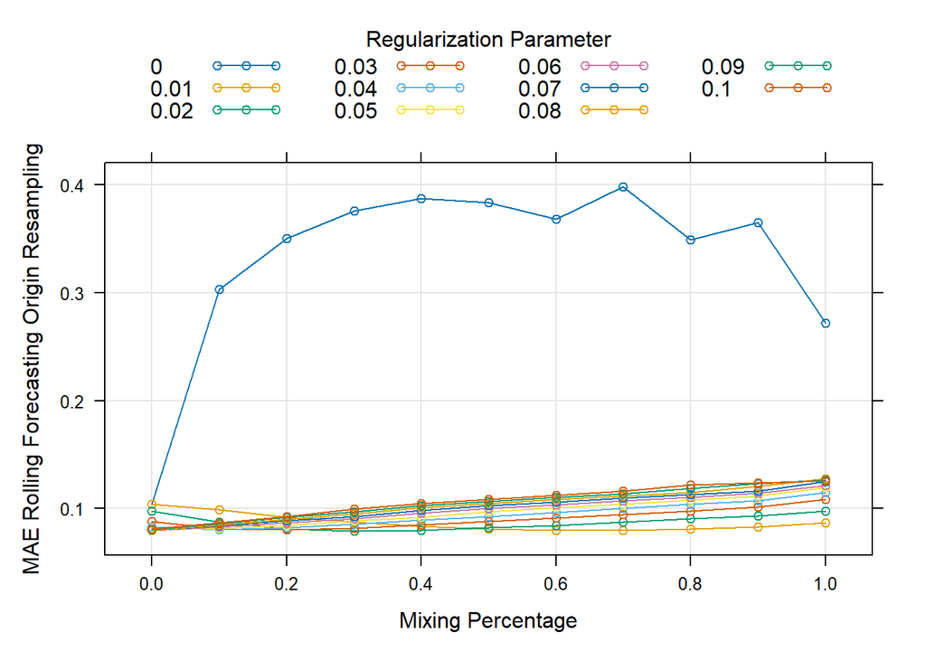

```r
plot(elastic_grid)
```

To further understand the model’s predictive performance, we visualize the predicted vs actual values of `Sales` for the validation dataset (`val_cv`) using the Grid Search approach, which achieved the best performance.

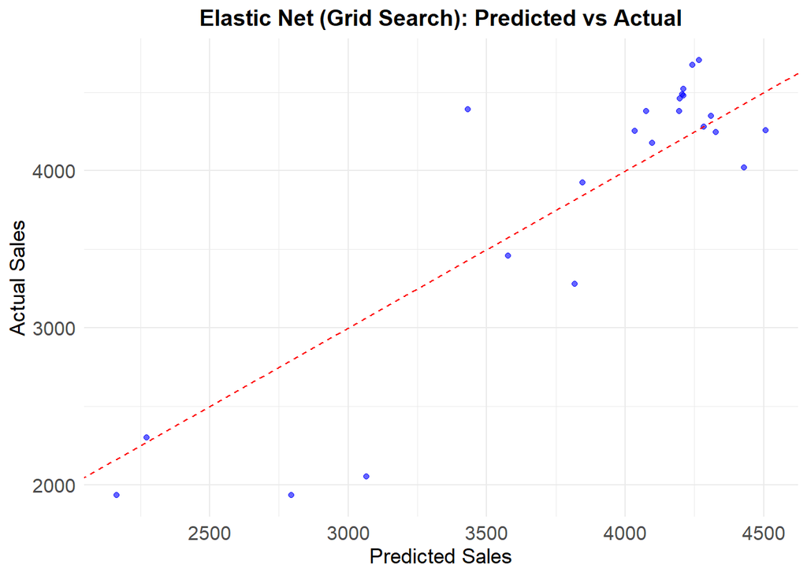

```r
# Plot predicted vs actual values
ggplot(val_cv, aes(x = elastic_grid_pred, y = Sales)) +
  geom_point(color = "blue", alpha = 0.6) +
  geom_abline(slope = 1, intercept = 0, color = "red", linetype = "dashed") +
  labs(
    title = "Elastic Net (Grid Search): Predicted vs Actual",
    x = "Predicted Sales",
    y = "Actual Sales"
  ) +
  theme_minimal() +
  theme(
    plot.title = element_text(hjust = 0.5, size = 14, face = "bold"),
    axis.text = element_text(size = 12),
    axis.title = element_text(size = 13)
  )
```

Each blue point represents an individual observation, while the red dashed line indicates the ideal scenario where predictions perfectly match the actual values.

From the plot, we observe that **most points cluster closely around the diagonal red line**, signifying strong predictive accuracy. However, some deviations are visible.

We can also assess predictive accuracy by **plotting the predicted and real time series**:

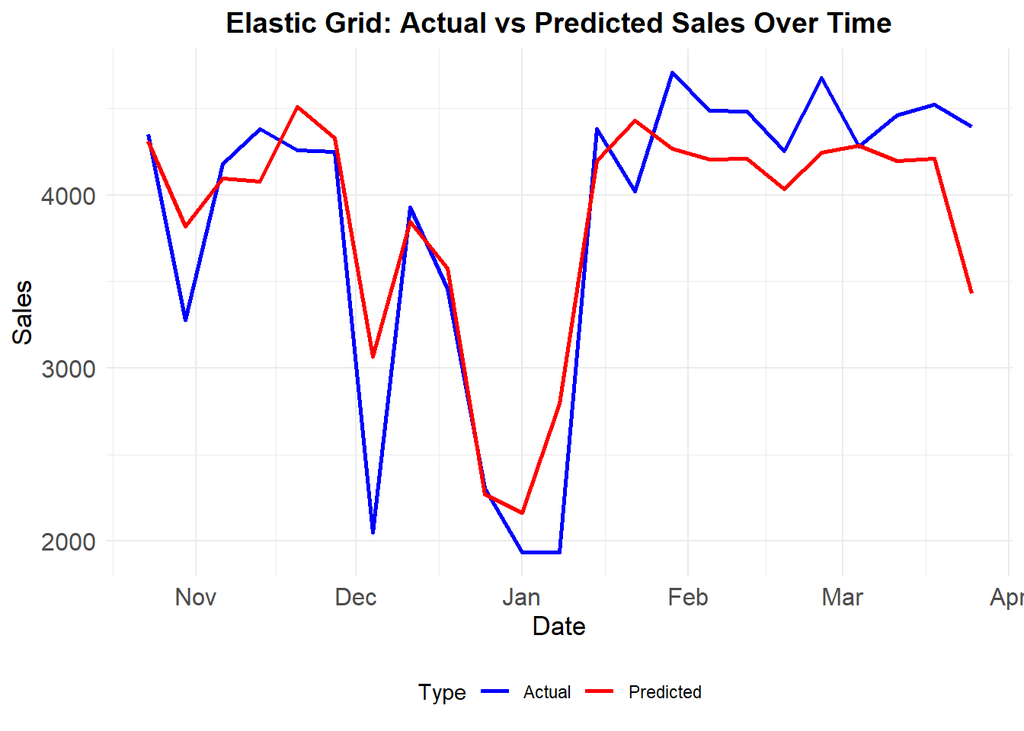

```r
# Create time series plot of actual vs predicted sales
ggplot(val_cv, aes(x = Monday_date)) +
  geom_line(aes(y = Sales, color = "Actual"), linewidth = 1) +
  geom_line(aes(y = elastic_grid_pred, color = "Predicted"), linewidth = 1) +
  scale_color_manual(values = c("Actual" = "blue", "Predicted" = "red")) +
  labs(
    title = "Elastic Grid: Actual vs Predicted Sales Over Time",
    x = "Date",
    y = "Sales",
    color = "Type"
  ) +
  theme_minimal() +
  theme(
    plot.title = element_text(hjust = 0.5, size = 14, face = "bold"),
    axis.text = element_text(size = 12),
    axis.title = element_text(size = 13),
    legend.position = "bottom"
  )
```

As we can see, **the model’s prediction closely follows the actual values**, although:

- It does not identify the noticeable drop at the beginning of December.
- It **underestimates the effect of Christmas** on sales at the second week of January.
- It **overestimates the effect of Easter** at the end of March.

### Extracting Selected Features

In this section, we extract **the features selected by the elastic net** and use them to define a new formula to be used with Machine Learning models (which have no inherent feature selection):

```r
# Extract coefficients from the elastic net model
coef_elastic <- coef(elastic_grid$finalModel, elastic_grid$bestTune$lambda)
coef_elastic <- as.matrix(coef_elastic)

# Get feature names (excluding intercept)
selected_features <- rownames(coef_elastic)[abs(coef_elastic) > 0][-1]  # Remove intercept
cat("\nSelected Features:\n")
```

```
##
## Selected Features:
```

```r
print(selected_features)
```

```
##  [1] "log(Affiliates_investment + 1)"
##  [2] "log(Meta_investment + 1)"
##  [3] "log(sea_brand + 1)"
##  [4] "log(TV_hbtv_investment + 1)"
##  [5] "log(TV_investment + 1)"
##  [6] "log(GBP + 1)"
##  [7] "log(web_visits + 1)"
##  [8] "log(sea_brand_lag1 + 1)"
##  [9] "log(sea_brand_lag2 + 1)"
## [10] "log(sea_other_investment_lag2 + 1)"
## [11] "log(TV_hbtv_investment_lag1 + 1)"
## [12] "log(TV_hbtv_investment_lag2 + 1)"
## [13] "TV_hbtv_investment_is_zero"
## [14] "seasonal_semiannual_sin"
## [15] "seasonal_quarterly_cos"
## [16] "seasonal_monthly_sin"
## [17] "seasonal_monthly_cos"
## [18] "is_christmas_vacation"
## [19] "is_easter_vacation"
## [20] "log(TV_hbtv_investment + 1):Stores"
## [21] "log(TV_investment + 1):Stores"
## [22] "log(Meta_investment + 1):Stores"
## [23] "log(Affiliates_investment + 1):log(OOH_investment + 1)"
```

```r
# Function to reverse log transformation in feature names
reverse_log_transform <- function(feature_name) {
  if(startsWith(feature_name, "log(") && endsWith(feature_name, " + 1)")) {
    # Extract the variable name from inside log()
    return(substr(feature_name, 5, nchar(feature_name) - 5))
  }
  return(feature_name)
}

# Process interaction terms for ML formula
process_interaction_ml <- function(feature_name) {
  if(grepl(":", feature_name)) {
    # Split the interaction term
    terms <- strsplit(feature_name, ":")[[1]]
    # Process each term
    processed_terms <- sapply(terms, reverse_log_transform)
    # Recombine with :
    return(paste(processed_terms, collapse = ":"))
  }
  return(reverse_log_transform(feature_name))
}

# Process features for ML formula (remove log transformations)
selected_features_ml <- sapply(selected_features, process_interaction_ml)

# Create ML formula (without transformations)
formula_ml_elastic_grid <- as.formula(paste("Sales ~",
                                          paste(selected_features_ml, collapse = " + ")))

# Create linear formula (keeping original transformations)
formula_linear_elastic_grid <- as.formula(paste("log(Sales) ~",
                                              paste(selected_features, collapse = " + ")))

# Print both formulas
cat("\nML Formula (no transformations):\n")
```

```
##
## ML Formula (no transformations):
```

```r
print(formula_ml_elastic_grid)
```

```
## Sales ~ Affiliates_investment + Meta_investment + sea_brand +
##     TV_hbtv_investment + TV_investment + GBP + web_visits + sea_brand_lag1 +
##     sea_brand_lag2 + sea_other_investment_lag2 + TV_hbtv_investment_lag1 +
##     TV_hbtv_investment_lag2 + TV_hbtv_investment_is_zero + seasonal_semiannual_sin +
##     seasonal_quarterly_cos + seasonal_monthly_sin + seasonal_monthly_cos +
##     is_christmas_vacation + is_easter_vacation + TV_hbtv_investment:Stores +
##     TV_investment:Stores + Meta_investment:Stores + Affiliates_investment:OOH_investment
```

```r
cat("\nLinear Formula (with original log transformations):\n")
```

```
##
## Linear Formula (with original log transformations):
```

```r
print(formula_linear_elastic_grid)
```

```
## log(Sales) ~ log(Affiliates_investment + 1) + log(Meta_investment +
##     1) + log(sea_brand + 1) + log(TV_hbtv_investment + 1) + log(TV_investment +
##     1) + log(GBP + 1) + log(web_visits + 1) + log(sea_brand_lag1 +
##     1) + log(sea_brand_lag2 + 1) + log(sea_other_investment_lag2 +
##     1) + log(TV_hbtv_investment_lag1 + 1) + log(TV_hbtv_investment_lag2 +
##     1) + TV_hbtv_investment_is_zero + seasonal_semiannual_sin +
##     seasonal_quarterly_cos + seasonal_monthly_sin + seasonal_monthly_cos +
##     is_christmas_vacation + is_easter_vacation + log(TV_hbtv_investment +
##     1):Stores + log(TV_investment + 1):Stores + log(Meta_investment +
##     1):Stores + log(Affiliates_investment + 1):log(OOH_investment +
##     1)
```

## Random Forest

### Random Forest With All Features

Random Forest is an ensemble learning method that combines multiple decision trees to achieve better predictive performance and reduce overfitting. The algorithm relies on two key principles: **bagging** and **feature randomness**. These properties make it highly effective for both regression and classification tasks.

To establish a baseline, we train a Random Forest model using **default hyperparameters**. This serves as a reference point to measure the performance improvements achieved through hyperparameter tuning.

- **Number of Trees**: Default value (500 trees) is used.
- **mtry**: Number of predictors randomly sampled at each split is set to its default value (square root of the total number of predictors).
- When computing predictions on the validation set, it is not necessary to undo any transformation, since we are now using `formula_ml`.

```r
# Baseline Random Forest
set.seed(123)
rforest_baseline <- train(
  formula_ml,
  data = train_cv,
  method = "rf",
  metric = "MAE",
  trControl = ctrl
)
# Predict on val_cv
val_cv$rforest_baseline_pred <- predict(rforest_baseline, val_cv)

# Calculate MAE on val_cv
rforest_baseline_mae_val <- mean(abs(val_cv$rforest_baseline_pred - val_cv$Sales))
rforest_baseline_mae_val
```

```
## [1] 450.239
```

Now, using random forest with **grid search**, we will systematically explore a predefined range of hyperparameter values for `mtry` (2, 4, 6, 8). Note `ntree` must stay fixed due to limitations in caret.

```r
set.seed(123)
rforest_grid <- train(
  formula_ml,
  data = train_cv,
  method = "rf",
  tuneGrid = expand.grid(mtry = c(2, 4, 6, 8)),  # Only mtry parameter
  metric = "MAE",
  trControl = ctrl,
  ntree = 500  # Set ntree as a fixed parameter outside tuneGrid
)
# Predict on val_cv using the best model from Grid Search
val_cv$rforest_grid_pred <- predict(rforest_grid, val_cv)

# Calculate MAE on val_cv
rforest_grid_mae_val <- mean(abs(val_cv$rforest_grid_pred - val_cv$Sales))
rforest_grid_mae_val
```

```
## [1] 423.1052
```

The tuned model has a **lower value for MAE** on the validation set (423 instead of 450), showing the benefit of using grid search instead of fixed hyperparameter values. However, it is **still a higher error than elastic net**.

The MAE achieved udring cross-validation for different values of `mtry` is:

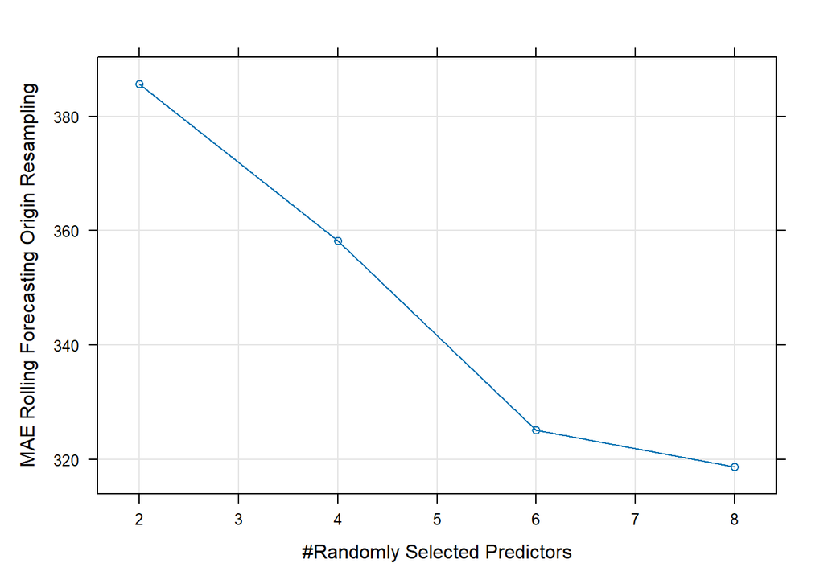

```r
plot(rforest_grid)
```

From the plot, we observe two things:

- The MAE seen during cross-validation (320) is significantly lower than the MAE of the validation set (423). This indicates **some level of overfitting** or particularities with the time periods covered by the validation set.
- The MAE decreases consistently as the number of predictors increases, reaching the lowest point at the maximum value of `mtry` (8). This pattern suggests that increasing the number of predictors improves the model’s predictive accuracy without introducing overfitting. Unlike typical scenarios where too many predictors can lead to overfitting, **Random Forest’s inherent robustness against overfitting allows it to benefit from larger `mtry` values in this dataset**.

To further understand the model’s predictive performance, we visualize the predicted vs actual values of `Sales` for the validation dataset (`val_cv`) using the grid search approach, which achieved the best performance.

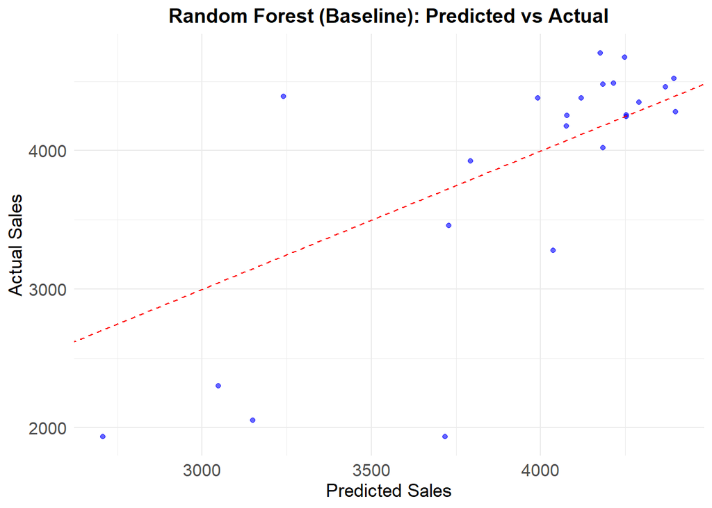

```r
# Plot predicted vs actual values for Baseline
ggplot(val_cv, aes(x = rforest_grid_pred, y = Sales)) +
  geom_point(color = "blue", alpha = 0.6) +
  geom_abline(slope = 1, intercept = 0, color = "red", linetype = "dashed") +
  labs(
    title = "Random Forest (Baseline): Predicted vs Actual",
    x = "Predicted Sales",
    y = "Actual Sales"
  ) +
  theme_minimal() +
  theme(
    plot.title = element_text(hjust = 0.5, size = 14, face = "bold"),
    axis.text = element_text(size = 12),
    axis.title = element_text(size = 13)
  )
```

To understand where the model is struggling, we will put **the predicted and real time series**:

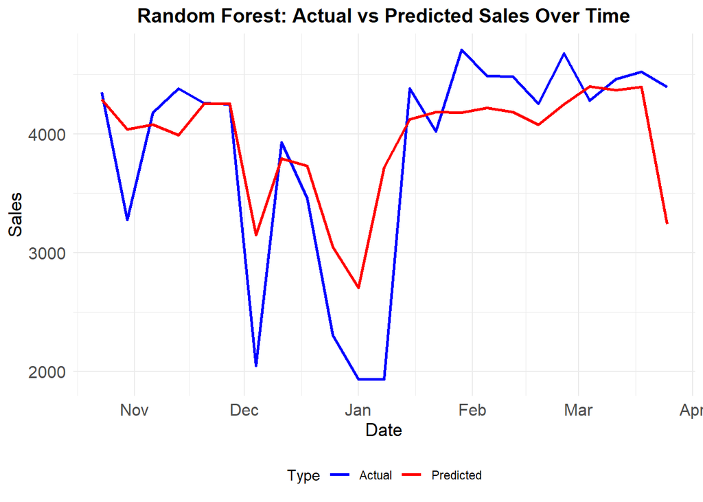

```r
# Create time series plot of actual vs predicted sales
ggplot(val_cv, aes(x = Monday_date)) +
  geom_line(aes(y = Sales, color = "Actual"), linewidth = 1) +
  geom_line(aes(y = rforest_grid_pred, color = "Predicted"), linewidth = 1) +
  scale_color_manual(values = c("Actual" = "blue", "Predicted" = "red")) +
  labs(
    title = "Random Forest: Actual vs Predicted Sales Over Time",
    x = "Date",
    y = "Sales",
    color = "Type"
  ) +
  theme_minimal() +
  theme(
    plot.title = element_text(hjust = 0.5, size = 14, face = "bold"),
    axis.text = element_text(size = 12),
    axis.title = element_text(size = 13),
    legend.position = "bottom"
  )
```

We notice the model:

### Random Forest With Selected Features

To address overfitting. we can try training the model on **subsets of selected features**:

- `formula_ml_no_vacation` and `formula_ml_no_seasonal`, which do not include the vacation flags or seasonal indicators.
- `formula_ml_elastic_grid`, which only includes the features selected by elastic net, but reverses the log transformations (in principle, not required for Machine Learning).
- `formula_linear`, which includes all features with the log transformations (required by linear models).
- `formula_linear_elastic_grid`, which only includes the features selected by elastic net and keeps the log transformations.

```r
# Train Random Forest model without vacation indicators
set.seed(123)
rf_no_vacation <- train(
  formula_ml_no_vacation,
  data = train_cv,
  method = "rf",
  metric = "MAE",
  trControl = ctrl
)
val_cv$rf_no_vacation_pred <- predict(rf_no_vacation, val_cv)
rf_no_vacation_mae_val <- mean(abs(val_cv$rf_no_vacation_pred - val_cv$Sales))

# Train Random Forest model without seasonality indicators
set.seed(123)
rf_no_seasonal <- train(
  formula_ml_no_seasonal,
  data = train_cv,
  method = "rf",
  metric = "MAE",
  trControl = ctrl
)
val_cv$rf_no_seasonal_pred <- predict(rf_no_seasonal, val_cv)
rf_no_seasonal_mae_val <- mean(abs(val_cv$rf_no_seasonal_pred - val_cv$Sales))

# Train Random Forest model with only elastic net features
set.seed(123)
rf_en_features <- train(
  formula_ml_elastic_grid,
  data = train_cv,
  method = "rf",
  metric = "MAE",
  trControl = ctrl
)
val_cv$rf_en_features_pred <- predict(rf_en_features, val_cv)
rf_en_features_mae_val <- mean(abs(val_cv$rf_en_features_pred - val_cv$Sales))

# Train Random Forest model with the linear formula (having log transformations)
set.seed(123)
rf_linear <- train(
  formula_linear,
  data = train_cv,
  method = "rf",
  metric = "MAE",
  trControl = ctrl
)
val_cv$rf_linear_pred <- exp(predict(rf_linear, val_cv)) - 1
rf_linear_mae_val <- mean(abs(val_cv$rf_linear_pred - val_cv$Sales))

# Train Random Forest model with the linear formula and features selected by elastic grid
set.seed(123)
rf_linear_en_features <- train(
  formula_linear_elastic_grid,
  data = train_cv,
  method = "rf",
  metric = "MAE",
  trControl = ctrl
)
val_cv$rf_linear_en_features_pred <- exp(predict(rf_linear_en_features, val_cv)) - 1
rf_linear_en_features_mae_val <- mean(abs(val_cv$rf_linear_en_features_pred - val_cv$Sales))

cat("\nRandom Forest Model without Vacation - Validation MAE:", rf_no_vacation_mae_val, "\n")
```

```
##
## Random Forest Model without Vacation - Validation MAE: 454.993
```

```r
cat("Random Forest Model without Seasonality - Validation MAE:", rf_no_seasonal_mae_val, "\n")
```

```
## Random Forest Model without Seasonality - Validation MAE: 462.2074
```

```r
cat("Random Forest Model with Elastic Net features - Validation MAE:", rf_en_features_mae_val, "\n")
```

```
## Random Forest Model with Elastic Net features - Validation MAE: 387.7697
```

```r
cat("Random Forest Model with Linear formula - Validation MAE:", rf_linear_mae_val, "\n")
```

```
## Random Forest Model with Linear formula - Validation MAE: 416.4552
```

```r
cat("Random Forest Model with Linear formula and Elastic Net features - Validation MAE:", rf_linear_en_features_mae_val, "\n")
```

```
## Random Forest Model with Linear formula and Elastic Net features - Validation MAE: 370.9809
```

We notice that:

- Using the **machine learning formula** and **elastic net features**, the MAE drops from the baseline (450) to 388, which is a significant improvement.
- Using the **linear formula (log transformations)** and **all features**, the MAE is 416, better than the baseline.
- Using the **linear formula (log transformations)** and **elastic net features**, the MAE is 371, which is better than the other random forest implementations, but still higher than elastic net.

This gives two very important conclusions:

- Despite not being necessary to satisfy assumptions, **log transformations can also be useful for Machine Learning**. We will try the linear formula in subsequent models.
- Performance can be improved by **training Machine Learning models with only the Elastic Net features**, which is something we will try from now on.

If we tune hyperparameters when using the linear formula and elastic net features, we get:

```r
set.seed(123)
rf_linear_en_features_grid <- train(
  formula_linear_elastic_grid,
  data = train_cv,
  method = "rf",
  tuneGrid = expand.grid(mtry = c(2, 4, 6, 8)),  # Only mtry parameter
  metric = "MAE",
  trControl = ctrl,
  ntree = 500  # Set ntree as a fixed parameter outside tuneGrid
)
# Predict on val_cv using the best model from Grid Search
val_cv$rf_linear_en_features_grid_pred <- exp(predict(rf_linear_en_features_grid, val_cv)) - 1

# Calculate MAE on val_cv
rf_linear_en_features_grid_mae_val <- mean(abs(val_cv$rf_linear_en_features_grid_pred - val_cv$Sales))
rf_linear_en_features_grid_mae_val
```

```
## [1] 418.2678
```

Which is higher than the model with default hyperparameters, so **leaving mtry as the default (square root of all features) is the best in this case**.

## XGBoost

### XGBoost With Default Configuration

**XGBoost** (Extreme Gradient Boosting) is a powerful ensemble learning technique based on decision trees. It is highly flexible and effective in handling large datasets, offering built-in support for feature selection and regularization.

We will train an XGBoost model using the default options, which **already perform hyperparameter tuning** automatically.

Based on our observations with random forest, we will train XGBoost on:

- Both the **machine learning formula** (no log transformations) and the **linear formula** (with log transformations).
- Both using **all features** and **selected features** by elastic net.

Results:

```r
# Print results
cat("XGBoost Baseline Model (ML formula, all features) - Validation MAE:", xgb_baseline_mae_val, "\n")
```

```
## XGBoost Baseline Model (ML formula, all features) - Validation MAE: 393.3966
```

```r
cat("XGBoost Baseline Model with  Elastic Net features - Validation MAE:", xgb_en_features_mae_val, "\n")
```

```
## XGBoost Baseline Model with  Elastic Net features - Validation MAE: 331.7412
```

```r
cat("XGBoost Model with Linear formula - Validation MAE:", xgb_linear_mae_val, "\n")
```

```
## XGBoost Model with Linear formula - Validation MAE: 424.8916
```

```r
cat("XGBoost Model with Linear formula and Elastic Net features - Validation MAE:", xgb_linear_en_features_mae_val, "\n")
```

```
## XGBoost Model with Linear formula and Elastic Net features - Validation MAE: 387.4716
```

In this case, we get the best results using the **machine learning formula** (no log transformations) and the **features selected by elastic net**, with a resulting MAE of 332. Surprisingly, this is still higher than elastic net (322).

To complement the analysis, we will now illustrates the relationship between the number of boosting rounds (`nrounds`) and the Mean Absolute Error (MAE) for the XGBoost model with elastic net features (the best model) under different configurations of `colsample_bytree`, `subsample`, `eta`, and `max_depth`:

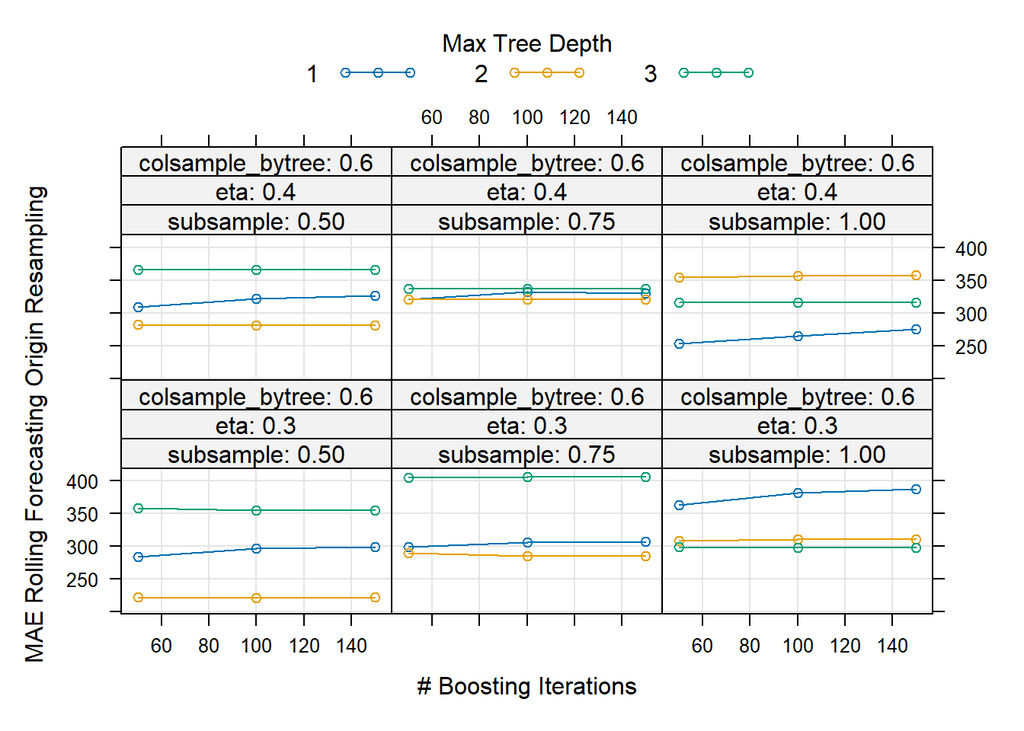

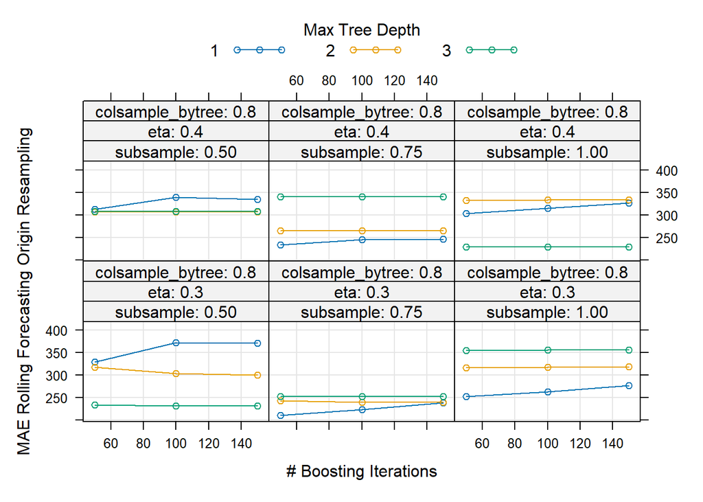

```r
# Plot tuning results for the XGBoost model with Elastic Net features
plot(xgb_en_features)
```

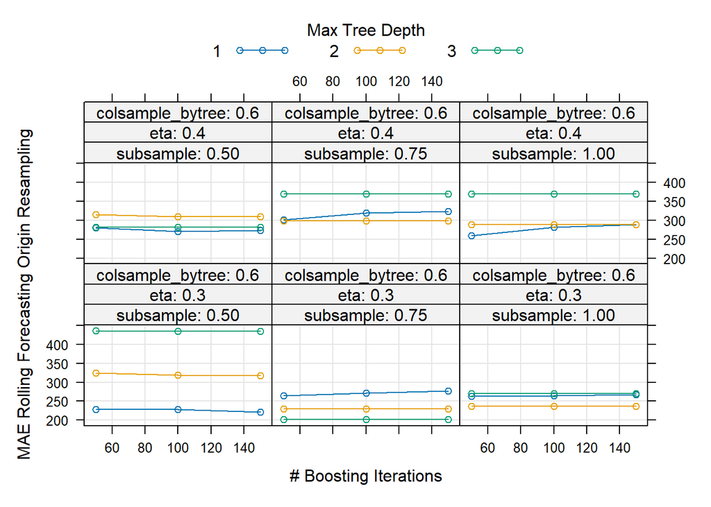

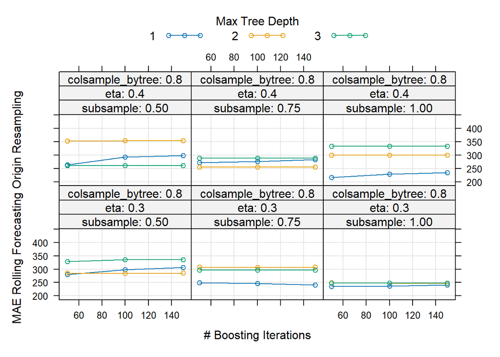

```r
plot(xgb_baseline)
```

We notice there is no clear impact for any of the hyperparameters individually. For example, the best `max_depth` depends on the values of the other parameters. In addition, like in random forest, we observe much lower MAE in cross-validation (lower than 250) than in the validation set (332).

Plotting the time series, we see **the model struggles in the same periods as random forest**:

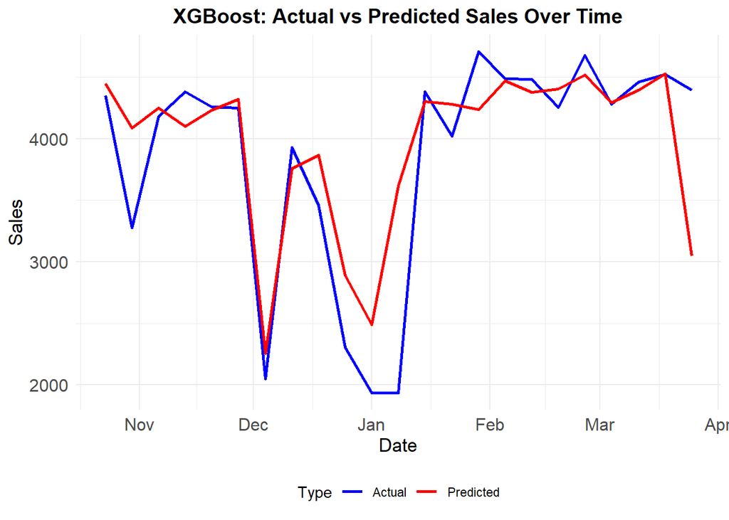

```r
# Create time series plot of actual vs predicted sales
ggplot(val_cv, aes(x = Monday_date)) +
  geom_line(aes(y = Sales, color = "Actual"), linewidth = 1) +
  geom_line(aes(y = xgb_en_features_pred, color = "Predicted"), linewidth = 1) +
  scale_color_manual(values = c("Actual" = "blue", "Predicted" = "red")) +
  labs(
    title = "XGBoost: Actual vs Predicted Sales Over Time",
    x = "Date",
    y = "Sales",
    color = "Type"
  ) +
  theme_minimal() +
  theme(
    plot.title = element_text(hjust = 0.5, size = 14, face = "bold"),
    axis.text = element_text(size = 12),
    axis.title = element_text(size = 13),
    legend.position = "bottom"
  )
```

### XGBoost With Regularization

We will now train XGBoost with a **cutom parameter grid** having:

- **For feature selection**: using `colsample_bytree` < 1 to randomly select features and increasing `gamma` to make the model more conservative about creating new splits.
- **For regularization**: using `subsample` < 1 to prevent overfitting.

Results:

```r
# Make predictions
val_cv$xgb_regularized_pred <- predict(xgb_regularized, val_cv)
xgb_regularized_mae_val <- mean(abs(val_cv$xgb_regularized_pred - val_cv$Sales))
cat("XGBoost Regularized Model - Validation MAE:", xgb_regularized_mae_val, "\n")
```

```
## XGBoost Regularized Model - Validation MAE: 400.3871
```

We see **the MAE on the validation set is higher than the previous models**, indicating the chosen hyperparameter grid for regularization does not generalize well.

## KNN

KNN is a non-parametric algorithm that predicts the value of a target variable based on the values of its nearest neighbors. Unlike Ridge Regression, KNN does not involve fitting a model but instead relies on distance calculations to identify neighbors. In our implementation:

- We will try **all the formulas** tested previously for XGBoost: with/without log transformations, with/without feature selection with elastic net.
- We will **preprocess the data by scaling and centering**, which is required by the kNN method because it is based on distances.

To establish a baseline, we first train the KNN model using a **fixed value** of `k = 5`. This serves as a reference point to measure the performance improvements achieved through hyperparameter tuning.

Results:

```r
# Print results
cat("KNN Baseline Model (ML formula, all features) - Validation MAE:", knn_baseline_mae_val, "\n")
```

```
## KNN Baseline Model (ML formula, all features) - Validation MAE: 431.8957
```

```r
cat("KNN Baseline Model with Elastic Net features - Validation MAE:", knn_en_features_mae_val, "\n")
```

```
## KNN Baseline Model with Elastic Net features - Validation MAE: 356.4174
```

```r
cat("KNN Model with Linear formula - Validation MAE:", knn_linear_mae_val, "\n")
```

```
## KNN Model with Linear formula - Validation MAE: 502.9946
```

```r
cat("KNN Model with Linear formula and Elastic Net features - Validation MAE:", knn_linear_en_features_mae_val, "\n")
```

```
## KNN Model with Linear formula and Elastic Net features - Validation MAE: 396.5361
```

The best results are achieved with the **machine learning formula** and the **elastic net feature selection** (just like XGBoost), with a MAE of 356. This is lower than random forest (371) but higher than elastic net (322) or XGBoost (332).

With **grid search**, we can systematically explore a predefined range of hyperparameter values for `k`, ensuring the optimal configuration within the specified grid is identified.

Results:

```r
# Print results
cat("KNN Grid Search - ML formula (all features) - Validation MAE:", knn_baseline_grid_mae_val, "\n")
```

```
## KNN Grid Search - ML formula (all features) - Validation MAE: 391.5362
```

```r
cat("KNN Grid Search - ML formula with Elastic Net features - Validation MAE:", knn_en_features_grid_mae_val, "\n")
```

```
## KNN Grid Search - ML formula with Elastic Net features - Validation MAE: 306.971
```

```r
cat("KNN Grid Search - Linear formula - Validation MAE:", knn_linear_grid_mae_val, "\n")
```

```
## KNN Grid Search - Linear formula - Validation MAE: 479.3089
```

```r
cat("KNN Grid Search - Linear formula with Elastic Net features - Validation MAE:", knn_linear_en_features_grid_mae_val, "\n")
```

```
## KNN Grid Search - Linear formula with Elastic Net features - Validation MAE: 466.3355
```

```r
# Print best k values for each model
cat("\nBest k values:\n")
```

```
##
## Best k values:
```

```r
cat("ML formula (all features):", knn_baseline_grid$bestTune$k, "\n")
```

```
## ML formula (all features): 3
```

```r
cat("ML formula with Elastic Net features:", knn_en_features_grid$bestTune$k, "\n")
```

```
## ML formula with Elastic Net features: 3
```

```r
cat("Linear formula:", knn_linear_grid$bestTune$k, "\n")
```

```
## Linear formula: 15
```

```r
cat("Linear formula with Elastic Net features:", knn_linear_en_features_grid$bestTune$k, "\n")
```

```
## Linear formula with Elastic Net features: 19
```

The best formula is still the one considering the original variables (no log) and the elastic net features. With this, we get a **surprisingly low MAE of 307**, which is the best so far.

This is the evolution of the cross-validation MAE during hyperparameter tuning:

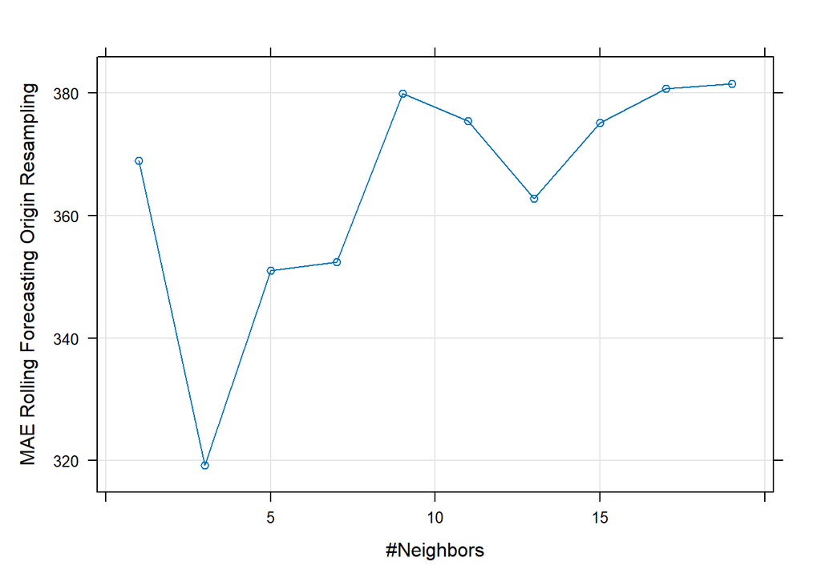

```r
plot(knn_en_features_grid)
```

Scatter plot of actual and predicted values:

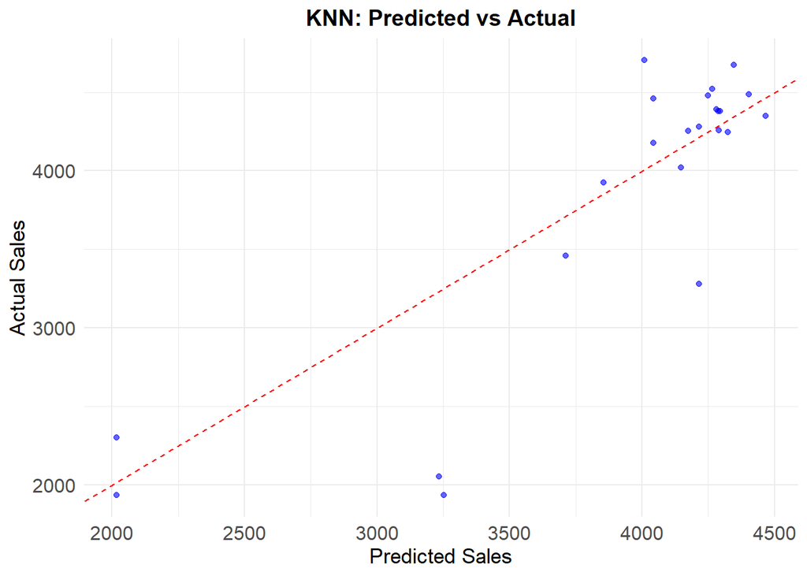

```r
# Plot predicted vs actual values for Random Search
ggplot(val_cv, aes(x = knn_en_features_grid_pred, y = Sales)) +
  geom_point(color = "blue", alpha = 0.6) +
  geom_abline(slope = 1, intercept = 0, color = "red", linetype = "dashed") +
  labs(
    title = "KNN: Predicted vs Actual",
    x = "Predicted Sales",
    y = "Actual Sales"
  ) +
  theme_minimal() +
  theme(
    plot.title = element_text(hjust = 0.5, size = 14, face = "bold"),
    axis.text = element_text(size = 12),
    axis.title = element_text(size = 13)
  )
```

Time-series plot:

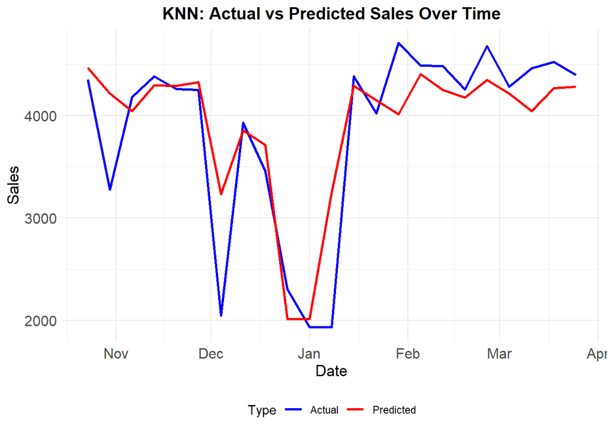

```r
# Create time series plot of actual vs predicted sales
ggplot(val_cv, aes(x = Monday_date)) +
  geom_line(aes(y = Sales, color = "Actual"), linewidth = 1) +
  geom_line(aes(y = knn_en_features_grid_pred, color = "Predicted"), linewidth = 1) +
  scale_color_manual(values = c("Actual" = "blue", "Predicted" = "red")) +
  labs(
    title = "KNN: Actual vs Predicted Sales Over Time",
    x = "Date",
    y = "Sales",
    color = "Type"
  ) +
  theme_minimal() +
  theme(
    plot.title = element_text(hjust = 0.5, size = 14, face = "bold"),
    axis.text = element_text(size = 12),
    axis.title = element_text(size = 13),
    legend.position = "bottom"
  )
```

The predictions is now much closer to the real value.

## Neural Networks

Neural Networks are powerful models capable of capturing non-linear relationships in data. They consist of multiple layers of interconnected nodes (neurons) and require careful hyperparameter tuning to achieve optimal performance. The primary hyperparameters to tune for Neural Networks include the number of hidden units (neurons), learning rate, and the number of epochs.

To establish a baseline, we train a Neural Network model using a **fixed architecture** with a single hidden layer of 10 neurons and **default parameters** for the learning rate and epochs. This serves as a reference point to measure the performance improvements achieved through hyperparameter tuning.

- **Chosen Hyperparameters**:
  - **Size**: Number of neurons in the hidden layer, set to 10 for the baseline.
  - **Decay**: Regularization parameter to prevent overfitting, set to 0.01.
- **Formulas**: Based on our previous experience, we will consider only the machine learning formulas (no log transformations) but with all features or only selected features.
- **Preprocessing**: Just like kNN, neural networks benefit from having scaled and centered data.

```r
# Baseline Neural Network with ML formula (all features)
set.seed(123)
nnet_baseline <- train(
  formula_ml,
  data = train_cv,
  method = "nnet",
  linout = TRUE,  # Regression output
  tuneGrid = expand.grid(size = 10, decay = 0.01),  # Fixed size and decay
  metric = "MAE",
  trace = FALSE,  # Suppress training output
  trControl = ctrl,
  preProcess = c("center", "scale")  # Added preprocessing
)
val_cv$nnet_baseline_pred <- predict(nnet_baseline, val_cv)
nnet_baseline_mae_val <- mean(abs(val_cv$nnet_baseline_pred - val_cv$Sales))

# Neural Network with ML formula and elastic net features
set.seed(123)
nnet_en_features <- train(
  formula_ml_elastic_grid,
  data = train_cv,
  method = "nnet",
  linout = TRUE,  # Regression output
  tuneGrid = expand.grid(size = 10, decay = 0.01),  # Fixed size and decay
  metric = "MAE",
  trace = FALSE,  # Suppress training output
  trControl = ctrl,
  preProcess = c("center", "scale")  # Added preprocessing
)
val_cv$nnet_en_features_pred <- predict(nnet_en_features, val_cv)
nnet_en_features_mae_val <- mean(abs(val_cv$nnet_en_features_pred - val_cv$Sales))

# Print results
cat("Neural Network Baseline Model (ML formula, all features) - Validation MAE:", nnet_baseline_mae_val, "\n")
```

```
## Neural Network Baseline Model (ML formula, all features) - Validation MAE: 636.5101
```

```r
cat("Neural Network Model with Elastic Net features - Validation MAE:", nnet_en_features_mae_val, "\n")
```

```
## Neural Network Model with Elastic Net features - Validation MAE: 391.7063
```

We notice using **only elastic net features** improves results, reducing the MAE to 392. However, this is higher than other methods.

With **grid Search**, we can systematically explore a predefined range of hyperparameter values for the number of neurons (`size`) and the regularization parameter (`decay`):

- **Size Range**: A grid of values (5, 10, 15) is tested to explore different network capacities.
- **Decay Range**: Regularization values (0.001, 0.01, 0.1) are tested to manage overfitting.

```r
# Grid Search for Neural Networks
set.seed(123)
nnet_grid <- train(
  formula_ml_elastic_grid,
  data = train_cv,
  method = "nnet",
  linout = TRUE,  # Regression output
  tuneGrid = expand.grid(
    size = c(5, 10, 15),  # Number of neurons
    decay = c(0.001, 0.01, 0.1)  # Regularization parameter
  ),
  metric = "MAE",
  trace = FALSE,
  trControl = ctrl,
  preProcess = c("center", "scale")
)
# Predict on val_cv using the best model from Grid Search
val_cv$nnet_grid_pred <- predict(nnet_grid, val_cv)

# Calculate MAE on val_cv
nnet_grid_mae_val <- mean(abs(val_cv$nnet_grid_pred - val_cv$Sales))
nnet_grid_mae_val
```

```
## [1] 346.0074
```

With grid search, we **lower the MAE to 346**, but this is still higher than the best MAE of other methods such as elastic net, XGBoost or KNN.

To complement the analysis, a plot showing the relationship between the number of neurons (`size`) and the Mean Absolute Error (MAE) for different regularization parameters (`decay`) is included:

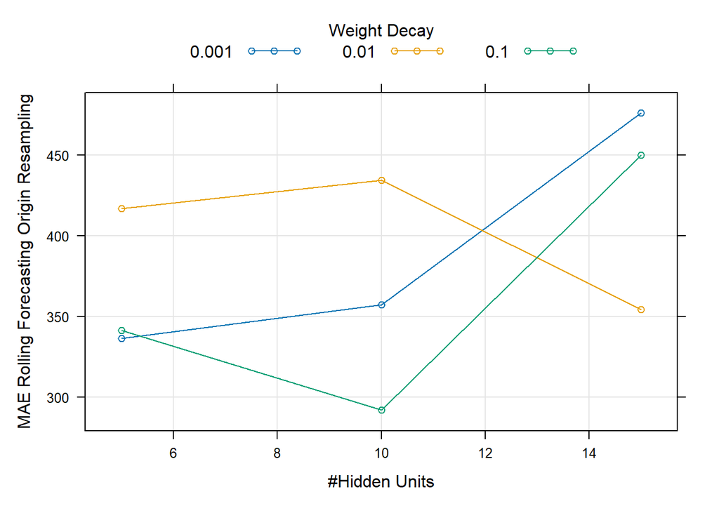

```r
plot(nnet_grid)
```

## Ensemble Model

### Introduction

The ensemble model employs **Weighted Averaging** and **Stacking** to evaluate its predictive capabilities.

### Ensemble Model With Equal Weights

To implement this ensemble, predictions from all models are **averaged equally** to produce an ensemble prediction.

```r
# Collect predictions from individual models
ensemble_data <- val_cv %>%
  select(Sales,
         elastic = elastic_grid_pred,
         rf = rf_linear_en_features_pred,
         xgb = xgb_en_features_pred,
         knn = knn_en_features_grid_pred,
         nnet = nnet_grid_pred)

# Simple Average Ensemble
ensemble_data <- ensemble_data %>%
  mutate(ensemble_avg = (elastic + rf + xgb + knn + nnet) / 5)
mae_avg <- mean(abs(ensemble_data$ensemble_avg - ensemble_data$Sales))
mae_avg
```

```
## [1] 300.6478
```

We notice **the MAE is 301**, which is lower than the lowest MAE of each individual model, and particularly KNN (which had 307).

### Ensemble Model With Weights

In this approach, **weights are assigned to each model based on their validation MAE**. Better-performing models have higher weights.

```r
# 2. Weighted Ensemble (weights based on inverse MAE)
# Calculate individual MAEs
mae_elastic <- mean(abs(ensemble_data$elastic - ensemble_data$Sales))
mae_rf <- mean(abs(ensemble_data$rf - ensemble_data$Sales))
mae_xgb <- mean(abs(ensemble_data$xgb - ensemble_data$Sales))
mae_knn <- mean(abs(ensemble_data$knn - ensemble_data$Sales))
mae_nnet <- mean(abs(ensemble_data$nnet - ensemble_data$Sales))

# Calculate weights (inverse of MAE)
weights <- c(1/mae_elastic, 1/mae_rf, 1/mae_xgb, 1/mae_knn, 1/mae_nnet)
weights <- weights / sum(weights)  # Normalize weights

# Apply weighted ensemble
ensemble_data <- ensemble_data %>%
  mutate(ensemble_weighted =
           weights[1] * elastic +
           weights[2] * rf +
           weights[3] * xgb +
           weights[4] * knn +
           weights[5] * nnet)
mae_weighted <- mean(abs(ensemble_data$ensemble_weighted - ensemble_data$Sales))
mae_weighted
```

```
## [1] 298.7548
```

With weighted averages, **MAE is dropped to 299**.

### Ensemble Model With Stacking

**Stacking** uses predictions from individual models as input features for a meta-model (e.g., Ridge Regression) to learn the best combination of predictions.

```r
# 3. Stacking Ensemble using Ridge Regression
# Create training data for meta-model using cross-validation predictions
meta_train <- data.frame(
  Sales = train_cv$Sales,
  elastic = exp(predict(elastic_grid, train_cv)) - 1,
  rf = exp(predict(rf_linear_en_features, train_cv)) - 1,
  xgb = predict(xgb_en_features, train_cv),
  knn = predict(knn_en_features_grid, train_cv),
  nnet = predict(nnet_grid, train_cv)
)

# Train meta-model (Ridge Regression)
# Grid of lambda values for Ridge
lambda_grid <- expand.grid(alpha = 0,  # Ridge regression
                          lambda = 10^seq(-4, -1, length.out = 10))

meta_model <- train(
  Sales ~ .,
  data = meta_train,
  method = "glmnet",
  tuneGrid = lambda_grid,
  trControl = trainControl(method = "cv", number = 5),
  metric = "MAE"
)

# Make predictions with stacking ensemble
ensemble_data$ensemble_stacking <- predict(meta_model,
                                         select(ensemble_data, -Sales,
                                               -ensemble_avg, -ensemble_weighted))
mae_stacking <- mean(abs(ensemble_data$ensemble_stacking - ensemble_data$Sales))
mae_stacking
```

```
## [1] 307.3553
```

The meta-model has a validation MAE of 307, which is higher than the weighted ensemble.